# STATS 306 Final Project: Chicago Traffic Accidents 2019

# Contributions

| Name | Contributions |
| --- | --- |
| Nicolas Reddig Figueroa | Writing of section templates, "Are speed limits correlated with crash severity?" |
| Samuel Cummins | Writing of section templates, "When is it most dangerous to drive?" |
| Preetha Pamidighantam | Introduction and conclusion, "What are the most dangerous weather, lighting, and road conditions to drive in?" |
| Kevin Hao En Tan | Compilation of report, markdown, "Where are the most accident-prone areas in Chicago?" |

Nicolas Reddig Figueroa, Samuel Cummins, Preetha Pamidighantam, and Kevin Hao En Tan all contributed equally in this project.

# Introduction

The Chicago Police Department collects crash data on city streets within the Chicago city limits and within the department’s jurisdiction. Excluding crashes on interstate highways, freeway ramps, and on local roads along the City boundary, the dataset includes crashes either self-reported by the driver involved or the reporting police officer at the site of the crash. Crash parameters like crash time, crash location, injury type, street conditions, weather conditions, posted speed limits, etc. are reported as best as possible by the electronic crash reporting system (E-Crash) and the reporting individual. The dataset provides a rich source of information that can be analyzed to find which parameters are correlated with the highest frequency of crashes. Primary examination of the dataset prompted questions such as “Which external conditions are correlated with more crashes?”, “When do the most crashes occur?”, and “Where do the most crashes occur?”. These initial observations motivated the main questions of this analysis:

1. What are the most dangerous speeds to drive at? Are speed limits correlated with crash severity?
2. When is it most dangerous to drive?
3. What are the most dangerous weather, lighting, and road conditions to drive in?
4. Where are the most accident-prone areas in Chicago?

# Package Loading, Data Import, Data Tidying

## Package Loading

In order to analyze Chicago Traffic the following packages were utilized:

[output not shown]

We also change the scale of plots displayed to better display the visualizations shown.

```r
library(tidyverse)
library(lubridate)
#install.packages("ggmap")
library(ggmap)
#install.packages("ggpubr")
library(ggpubr)
#install.packages("dbscan")
library(dbscan)

options(jupyter.plot_scale=1.5)
```

## Data Import/Preparation and Description of Variables

The dataset `chicagotraffic2019` contains crashes occurring inside the jurisdiction of the Chicago Police Department and therefore inside the city limits of Chicago during the year 2019. We name the main tibble `traffic`.

The question: “Are speed limits correlated with crash severity?” utilized the following variables:

| Variable Name | Summary | Explanation |
| --- | --- | --- |
| `POSTED_SPEED_LIMIT` | Categorical, nearest speed limit posting to the crash site. | This variable was used to approximate the speeds of vehicles involved in accidents. |
| `DAMAGE` | Categorical, amount of damage in US dollars caused by the crash was less than 500, between 500 and 1500 or greater than 1500. | Used to categorize accidents based on value of damage caused |
| `INJURIES_FATAL` | Discrete, number of fatal injuries in a given crash. | Used to obtain number of injuries of this severity for a given crash. |
| `INJURIES_INCAPACITATING` | Discrete, number of incapacitating injuries in a given crash. | Used to obtain number of injuries of this severity for a given crash. |
| `INJURIES_TOTAL` | Discrete, number of total injuries in a given crash. | Used to obtain number of injuries for a given crash. |

The question: “When is it most dangerous to drive” utilized the following variables:

| Variable Name | Summary | Explanation |
| --- | --- | --- |
| `CRASH_DATE` | A datetime variable that includes the year, month, day, hour, minute, and second of the time of the crash report. | This variable was used to mark certain days as holiday times. |
| `CRASH_MONTH` | An integer representing the month of the year when the crash was reported. | This variable was used to categorize accidents according to the month they occured in. |
| `CRASH_HOUR` | An integer representing the hour of the day when the crash was reported. | This variable was used to determine crash patterns based on time of day and also to get the times around sunrise and sunset for the chart based on whether a driver had the sun in their eyes. |
| `STREET_DIRECTION` | A factor of characters representing the direction of the road on which the primarily responsible vehicle was traveling (`E` for east, `W` for west, etc.). | This variable was used to determine if the at-fault driver was facing the sun at the time of the incident. |
| `TRAFFICWAY_TYPE` | A factor representing the type of trafficway on which the accident occurred (intersections, parking lots, street types, etc.) | This variable was used in the holidays table to determine whether different trafficways saw abnormal traffic patterns during the holidays. |

The question: "What are the most dangerous weather, lighting, and road conditions to drive in?" utilized the following additional variables:

| Variable Name | Summary | Explanation |
| --- | --- | --- |
| `WEATHER_CONDITIONS` | Categorical variable that describes the weather conditions at the site and time of the crash. Examples include “Clear”, “Snow”, “Cloudy/Overcast”, etc. | To calculate which weather conditions were associated with the highest proportion and highest severity of crashes. |
| `LIGHTING_CONDITIONS` | Categorical variable that describes the natural and artificial lighting conditions at the site and time of the crash. Examples include “Darkness”, “Darkness with Lighted Roads”, “Daylight”, etc. | To deduce which lighting conditions were associated with the highest proportion and highest severity of crashes. |
| `ROADWAY_SURFACE_COND` | Categorical variable that describes the road surface conditions. Examples include “Dry”, “Wet”, “Ice”, etc. | To work out which road surface conditions were associated with the highest proportion and highest severity of crashes. |
| `ROAD_DEFECT` | Categorical variable that describes if the road has any defects. Examples include “Rut/Holes”, “Worn Surface”, “No Defects”, etc. | To find out which road defects were associated with the highest proportion and highest severity of crashes. |
| `INJURIES_TOTAL` | Integer variable that describes the total number of injuries, disregarding the type of injury, that resulted from the crash. | Used to obtain number of injuries for a given crash. |

The question: "Where are the most accident-prone areas in Chicago?" utilized the following additional variables:

| Variable Name | Summary | Explanation |
| --- | --- | --- |
| `LATITUDE` | Double, the angular distance of a place north or south of the earth's equator. | Used to obtain location for a given accident. |
| `LONGITUDE` | Double, the angular distance of a place east or west of the earth's equator. | Used to obtain location for a given accident. |
| `FIRST_CRASH_TYPE` | Categorical, primary classification of crashes. Examples include "PEDESTRIAN", "ANGLE", "PARKED MOTOR VEHICLE", etc. | Used to group accidents by crash type to determine how common each crash type was. |
| `INJURIES_FATAL` | Discrete, number of fatal injuries in a given crash. | Used to obtain number of injuries of this severity for a given crash. |
| `INJURIES_INCAPACITATING` | Discrete, number of incapacitating injuries in a given crash. | Used to obtain number of injuries of this severity for a given crash. |
| `INJURIES_TOTAL` | Discrete, number of total injuries in a given crash. | Used to obtain number of injuries for a given crash. |

```r
traffic <- read_csv("chicagotraffic2019.csv")
traffic %>% head
```

A tibble: 6 × 40

| X1 <dbl> | CRASH_RECORD_ID <chr> | RD_NO <chr> | CRASH_DATE <chr> | POSTED_SPEED_LIMIT <dbl> | TRAFFIC_CONTROL_DEVICE <chr> | DEVICE_CONDITION <chr> | WEATHER_CONDITION <chr> | LIGHTING_CONDITION <chr> | FIRST_CRASH_TYPE <chr> | ... | INJURIES_NON_INCAPACITATING <dbl> | INJURIES_REPORTED_NOT_EVIDENT <dbl> | INJURIES_NO_INDICATION <dbl> | INJURIES_UNKNOWN <dbl> | CRASH_HOUR <dbl> | CRASH_DAY_OF_WEEK <dbl> | CRASH_MONTH <dbl> | LATITUDE <dbl> | LONGITUDE <dbl> | LOCATION <chr> |
| --- | --- | --- | --- | --- | --- | --- | --- | --- | --- | --- | --- | --- | --- | --- | --- | --- | --- | --- | --- | --- |
| 2 | 1560fb8a1e32b528fef8bfd677d2b3fc5ab37278b157fa5ecf66064359bdad3803b9d298d234eb31f463d08515c791b5627fbf7afea3765d1c1a9f3befc5bdcc | JC325941 | 06/27/2019 04:00:00 PM | 45 | NO CONTROLS | NO CONTROLS | CLEAR | DAYLIGHT | SIDESWIPE SAME DIRECTION | ... | 0 | 0 | 2 | 0 | 16 | 5 | 6 | NA | NA | NA |
| 5 | 00e47f189660cd8ba1e85fc63061bf1d8465184393f134fb8251ed7896a4ba9ed7c984ab51a01f564d6f4133c6ef8493b1a369743a4a308d4392900a286e160f | JC194776 | 03/21/2019 10:50:00 PM | 30 | TRAFFIC SIGNAL | FUNCTIONING PROPERLY | CLEAR | DARKNESS, LIGHTED ROAD | TURNING | ... | 0 | 0 | 2 | 0 | 22 | 5 | 3 | 41.74180 | -87.74095 | POINT (-87.740953581987 41.741803598989) |
| 8 | 0211e1f766f3940dfa87375661d25b716655e908c320cc46910e8fa5fb1f1e6a9d4f714d21e8e401ec9e0a12190b6cd9f6dbc97d32d0c0fc966a02ae516e782f | JC301403 | 06/11/2019 08:40:00 AM | 30 | TRAFFIC SIGNAL | FUNCTIONING PROPERLY | CLEAR | DAYLIGHT | REAR END | ... | 0 | 0 | 3 | 0 | 8 | 3 | 6 | 41.79478 | -87.62383 | POINT (-87.623828038036 41.794778764028) |
| 15 | 046c0f96fdf5f7384e026821bb23fdd56d610dce11247b4cf7072f4e0308cdf5865ee8f31d71792ef005d864c064aae933213ef5e4e87a9bb2247ffe0f56f245 | JC128226 | 01/24/2019 06:45:00 AM | 30 | NO CONTROLS | NO CONTROLS | CLEAR | DARKNESS, LIGHTED ROAD | REAR END | ... | 0 | 0 | 2 | 0 | 6 | 5 | 1 | 41.79478 | -87.62383 | POINT (-87.623828038036 41.794778764028) |
| 17 | 0564e565ebda939c88d5da6d613ac5789b702cbff5b8744552f9930bd571995afb81a895dfd2bc8a23e6cca53f8fc6a9afbeb38591781281a3c37ceba5cbcbd5 | JC541936 | 12/10/2019 03:15:00 PM | 20 | TRAFFIC SIGNAL | FUNCTIONING PROPERLY | CLEAR | DAYLIGHT | PEDESTRIAN | ... | 0 | 0 | 2 | 0 | 15 | 3 | 12 | 41.95420 | -87.66919 | POINT (-87.669192620028 41.954196228965) |
| 20 | 06d11d0ac4bf97a43f93b78768b225c91ba0579939a4fc92ba3f426a1353607f52a8f8536eefb3a7a3e75f553d1e941841ce5b26890e986b06ad85a716fa3a2c | JC263263 | 05/14/2019 07:30:00 PM | 20 | PEDESTRIAN CROSSING SIGN | FUNCTIONING PROPERLY | CLEAR | DAYLIGHT | PEDESTRIAN | ... | 1 | 0 | 2 | 0 | 19 | 3 | 5 | 41.95068 | -87.64378 | POINT (-87.64378474303 41.950676838996) |

## Data Tidying

The dataset Chicago Traffic 2019 is Tidy following the Tidy Data [spec](https://r4ds.had.co.nz/tidy-data.html). There was no need to pivot, lengthen or widen the data set. Each variable is segregated into a unique column and there are no duplicate entries where a variable is split across two rows.

# Question 1: What are the Most Dangerous Speeds to Drive At? Are Speed Limits Correlated With Crash Severity?

Although the posted speed limit related to an accident does not explicitly define the speed of the vehicle(s), it does give a sense of the general speed which was involved.

## Data Modification

```r
speed_limit_rounded_up <- traffic %>%
    filter(!is.na(INJURIES_TOTAL)) %>%
    mutate(POSTED_SPEED_LIMIT
            = POSTED_SPEED_LIMIT + (5 - POSTED_SPEED_LIMIT %% 5))
```

## How to Define Crash Severity

In the context of this dataset, the information present which can be applied to answering this question is the amount of damage in USD caused by an accident, fatal injuries, incapacitating and non incapacitating injuries. For the sake of this analysis, an accident can be labeled as severe if there is at least one injury, or if the damage caused by the crash is greater than 1500 USD.

## Does Speed (Speed Limit) Affect the Probability of an Injury in a Crash?

### Distribution of Accidents in Dataset

The first step in answering this question was to get a sense of how accidents in the dataset are distributed. The dataset includes mostly accidents on city streets as there are not many highways in this police jurisdiction. This bargraph leads to the conclusion that this question should be analyzed using percentages of crashes, opposed to raw numbers because of the uneven distribution between speed limits.

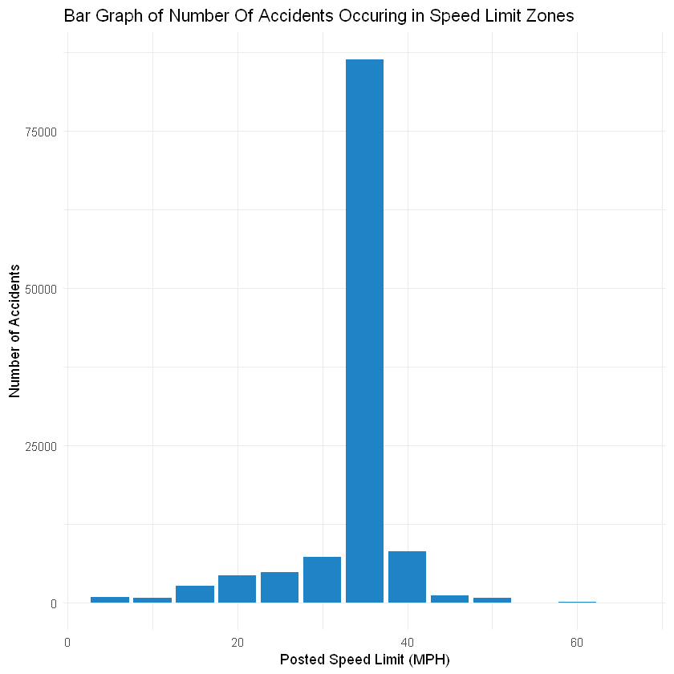

```r
speed_limit_rounded_up %>%
    ggplot(mapping=aes(x=POSTED_SPEED_LIMIT)) +
    geom_bar(fill="#2083C5") +
    labs(title="Bar Graph of Number Of Accidents Occuring in Speed Limit Zones",
        x="Posted Speed Limit (MPH)",
        y="Number of Accidents") +
    theme_minimal()
```

### Relating the Speed Limit of a Crash and the Likelihood of that Crash Resulting in Injury

In beginning to answer this question, we first tackle low hanging fruit. We examing how the speed limit of a crash relates the likelihood of that crash resulting in at least one injury. The data describing the number of injuries at each speed limit as shown below bears a similarity to the bar graph above which bodes well for any correlation.

```r
speed_limit_rounded_up %>% filter((INJURIES_FATAL > 0 | INJURIES_INCAPACITATING > 0)) %>%
    group_by(POSTED_SPEED_LIMIT) %>%
    summarize(ACCIDENTS_WITH_INJURIES=n())
```

A tibble: 11 × 2

| POSTED_SPEED_LIMIT <dbl> | ACCIDENTS_WITH_INJURIES <int> |
| --- | --- |
| 5 | 12 |
| 10 | 3 |
| 15 | 20 |
| 20 | 31 |
| 25 | 45 |
| 30 | 123 |
| 35 | 1592 |
| 40 | 227 |
| 45 | 32 |
| 50 | 23 |
| 60 | 4 |

The linear regression model for speed limit vs the probability of injury occuring has a fairly large R-squared of 0.8452 , indicating that there is a significant correlation between these two variables.

```
Call:
lm(formula = POSTED_SPEED_LIMIT ~ perc, data = perc_inj)

Residuals:
     Min       1Q   Median       3Q      Max
-15.1343  -3.5962  -0.2497   2.5070  19.3860

Coefficients:
            Estimate Std. Error t value Pr(>|t|)
(Intercept)    1.665      4.840   0.344    0.737
perc         235.858     30.431   7.751 8.82e-06 ***
---
Signif. codes:  0 '***' 0.001 '**' 0.01 '*' 0.05 '.' 0.1 ' ' 1

Residual standard error: 8.001 on 11 degrees of freedom
Multiple R-squared:  0.8452,	Adjusted R-squared:  0.8312
F-statistic: 60.07 on 1 and 11 DF,  p-value: 8.815e-06
```

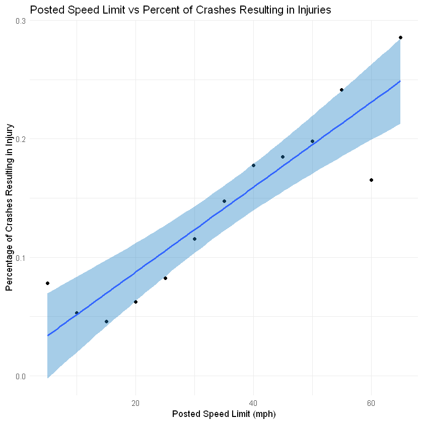

```r
perc_inj <- speed_limit_rounded_up %>%
    group_by(POSTED_SPEED_LIMIT) %>%
    summarize(total = n(), .groups="keep") %>%
    left_join(
        speed_limit_rounded_up %>% filter(INJURIES_TOTAL>0) %>%
        group_by(POSTED_SPEED_LIMIT) %>%
        summarize(crashes_with_injuries=n(), .groups="keep"),
    by=c("POSTED_SPEED_LIMIT")) %>%
    mutate(perc = crashes_with_injuries/total)

lmperc_inj <- lm(POSTED_SPEED_LIMIT ~ perc, perc_inj)
summary(lmperc_inj)

perc_inj %>% ggplot(mapping=aes(x=POSTED_SPEED_LIMIT, y=perc)) + geom_point() + geom_smooth(method="lm",fill="#2083C5") +
    labs(title="Posted Speed Limit vs Percent of Crashes Resulting in Injuries",
        x="Posted Speed Limit (mph)", y="Percentage of Crashes Resulting in Injury")+
    theme_minimal()
```

One thing to examine further, however, is the rather high minimum and maximum residual values. The boxplot of residuals for this linear regression model shows a median right around 0, which means that the model is a generally good one for the majority of the data. The first and third quartiles are fairly evenly spaced from the median which also indicates a good model, although there are two strong outliers which explains the high min and max values from the linear regression summary.

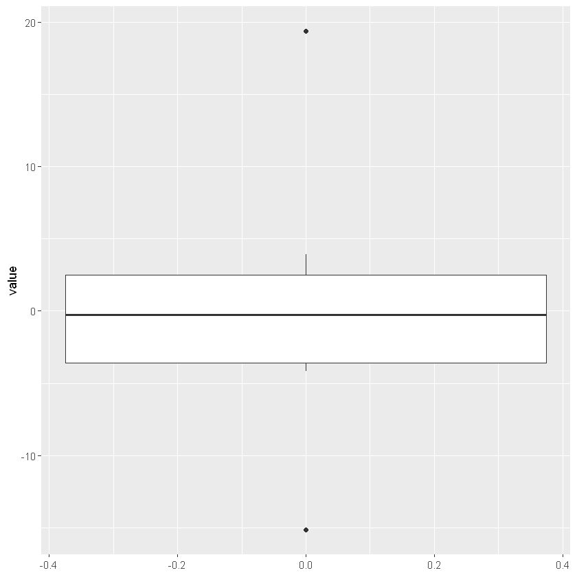

```r
as_tibble(lmperc_inj[['residuals']]) %>% ggplot(mapping = aes(y=value)) + geom_boxplot()
```

### Further Linear Regression Models

Further diving was required in order to describe just how far the relationship goes between speed and severity of a crash. The following two linear regression models are the relationships between the speed limit and probability of an accident having fatal or incapacitating injuries given that it does have an injury, and the speed limit and the average number of injuries at that speed.

This first model between speed and the probability of an injury being incapacitating or worse in a given accident is not so strong, the residuals are quite high along with a fairly low R-squared. This paired with a p-value of greater than 5% reinforces the conclusion that there is a weak postive correlation between speed and the probability of having a more severe injury in an accident.

```
Call:
lm(formula = POSTED_SPEED_LIMIT ~ perc, data = perc_severe)

Residuals:
    Min      1Q  Median      3Q     Max
-30.404  -1.621   2.902   8.928  15.873

Coefficients:
            Estimate Std. Error t value Pr(>|t|)
(Intercept)   -9.327     18.387  -0.507   0.6242
perc         275.844    123.729   2.229   0.0527 .
---
Signif. codes:  0 '***' 0.001 '**' 0.01 '*' 0.05 '.' 0.1 ' ' 1

Residual standard error: 14.71 on 9 degrees of freedom
  (2 observations deleted due to missingness)
Multiple R-squared:  0.3558,	Adjusted R-squared:  0.2842
F-statistic:  4.97 on 1 and 9 DF,  p-value: 0.05275
```

```
Warning message:
"Removed 2 rows containing non-finite values (stat_smooth)."
Warning message:
"Removed 2 rows containing missing values (geom_point)."
```

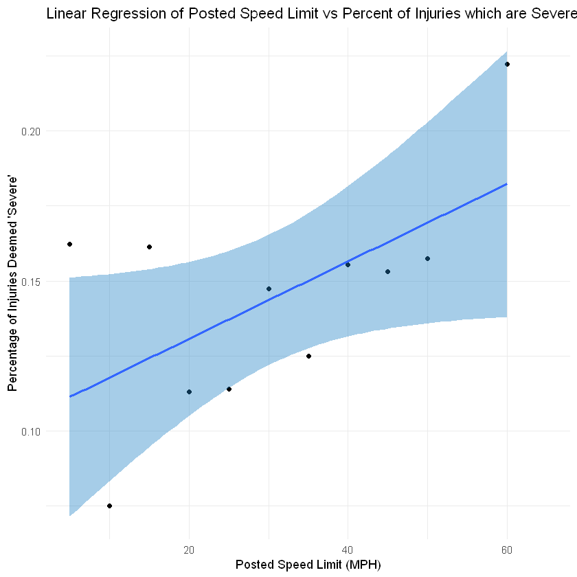

```r
perc_severe <- speed_limit_rounded_up %>% filter(INJURIES_TOTAL>0) %>%
    group_by(POSTED_SPEED_LIMIT) %>%
    summarize(total = n()) %>%
    left_join(
        speed_limit_rounded_up %>% filter((INJURIES_FATAL>0 | INJURIES_INCAPACITATING > 0)) %>%
        group_by(POSTED_SPEED_LIMIT) %>%
        summarize(crashes_with_injuries=n())
    ) %>%
    mutate(perc = crashes_with_injuries/total)
lmperc_severe <- lm(POSTED_SPEED_LIMIT ~ perc, perc_severe)
summary(lmperc_severe)

perc_severe %>% ggplot(mapping=aes(x=POSTED_SPEED_LIMIT, y=perc)) + geom_point() + geom_smooth(method="lm",fill="#2083C5") +
    labs(title="Linear Regression of Posted Speed Limit vs Percent of Injuries which are Severe",
        x="Posted Speed Limit (MPH)", y="Percentage of Injuries Deemed 'Severe'")+
    theme_minimal()
```

The last regression model for injuries intends to describe the relationship between speed of an accident and the number of injuries involved. This model lies somewhere between the previous two in terms of strength. The R-squared is fairly high at .63 and the residuals are evenly distributed around the mean, indicating a similar relationship as the first linear regression model; there is a strong positive correlation between the speed involved in an accident and the average number of injuries at that speed.

```
Call:
lm(formula = POSTED_SPEED_LIMIT ~ avg_inj, data = prob_injury)

Residuals:
     Min       1Q   Median       3Q      Max
-19.8624  -3.4779   0.4189   2.5588  21.8002

Coefficients:
            Estimate Std. Error t value Pr(>|t|)
(Intercept)   13.094      6.064   2.159  0.05377 .
avg_inj      105.369     24.118   4.369  0.00112 **
---
Signif. codes:  0 '***' 0.001 '**' 0.01 '*' 0.05 '.' 0.1 ' ' 1

Residual standard error: 12.3 on 11 degrees of freedom
Multiple R-squared:  0.6344,	Adjusted R-squared:  0.6012
F-statistic: 19.09 on 1 and 11 DF,  p-value: 0.00112
```

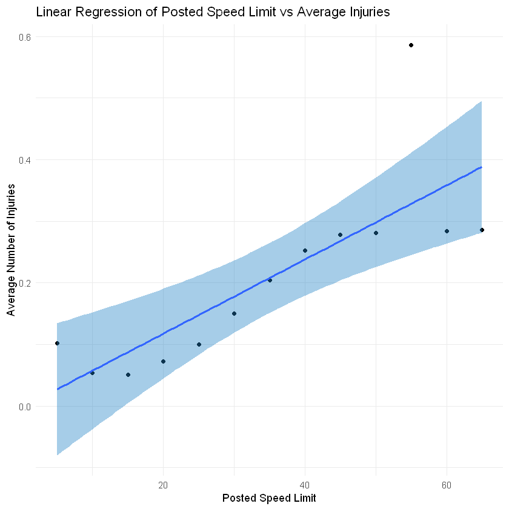

```r
prob_injury <- speed_limit_rounded_up %>% group_by(POSTED_SPEED_LIMIT) %>%
    summarize(avg_inj=sum(INJURIES_TOTAL, na.rm=TRUE)/n(), .groups="keep")

lminjury <- lm(POSTED_SPEED_LIMIT~avg_inj, prob_injury)
summary(lminjury)

prob_injury %>% ggplot(mapping=aes(x=POSTED_SPEED_LIMIT, y=avg_inj)) +
    geom_point() +
    geom_smooth(method="lm", fill="#2083C5") +
    theme_minimal() +
    labs(title="Linear Regression of Posted Speed Limit vs Average Injuries",
        x="Posted Speed Limit", y="Average Number of Injuries")
```

## Does Speed (Speed Limit) Affect the Amount of Damage Resulting From an Accident?

The final part of modeling crash severity is simpler, involving less variables but is interesting nonetheless. Although there are three levels of damage in the dataset, the highest damage level is used as a metric for severity. The linear regression relationship here shows a relatively evenly dispersed residuals and high R-squared describes a strong positive relationship between accident speed and the percentage of crashes with over 1500 USD in damage.

The scatterplot below is used to reinforce the previous conclusion about accident damage cost, showing that as the speed limit of an accident rises, one is more likely to cause more damage, which lines up with the intuition about this question. The probability of causing less than 1500 USD in damage has a moderately strong negative correlation with increasing speed involved in an accident.

```
Call:
lm(formula = POSTED_SPEED_LIMIT ~ PERC_OVER_1500, data = damage_by_speed %>%
    mutate(PERC_OVER_1500 = OVER_1500/TOTAL))

Residuals:
     Min       1Q   Median       3Q      Max
-25.7079  -2.3812   0.3804   4.9892  19.6909

Coefficients:
               Estimate Std. Error t value Pr(>|t|)
(Intercept)      -81.27      25.57  -3.179 0.008782 **
PERC_OVER_1500   197.79      43.13   4.586 0.000783 ***
---
Signif. codes:  0 '***' 0.001 '**' 0.01 '*' 0.05 '.' 0.1 ' ' 1

Residual standard error: 11.92 on 11 degrees of freedom
Multiple R-squared:  0.6566,	Adjusted R-squared:  0.6254
F-statistic: 21.03 on 1 and 11 DF,  p-value: 0.0007826
```

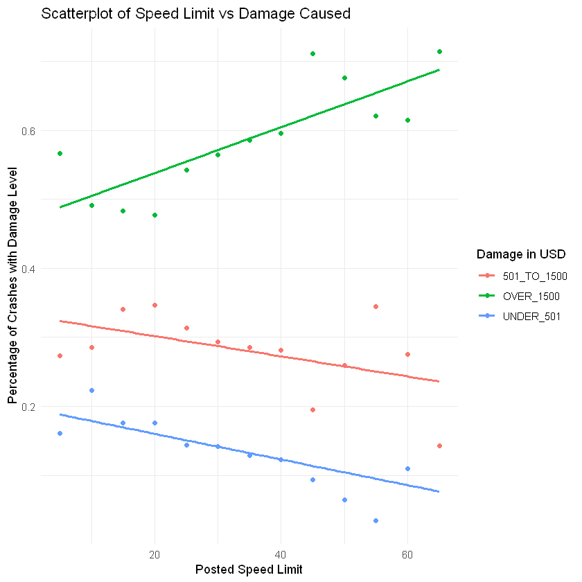

```r
damage_by_speed <- speed_limit_rounded_up %>% group_by(POSTED_SPEED_LIMIT, DAMAGE) %>%
    summarize(count = n(), .groups="keep") %>% spread(DAMAGE, count) %>%
    group_by(POSTED_SPEED_LIMIT) %>%
    rename("UNDER_501"= `$500 OR LESS`, "501_TO_1500"=`$501 - $1,500`, "OVER_1500"=`OVER $1,500`) %>%
    mutate(TOTAL=sum(.data[["UNDER_501"]], .data[["501_TO_1500"]], .data[["OVER_1500"]]))

lmsevere <- lm(POSTED_SPEED_LIMIT~PERC_OVER_1500, damage_by_speed %>% mutate(PERC_OVER_1500 = OVER_1500/TOTAL))
summary(lmsevere)


damage_by_speed %>% gather("DAMAGE", "COUNT", "UNDER_501":"OVER_1500") %>%
    mutate(PERCENTAGE=COUNT/TOTAL) %>%
    ggplot(mapping=aes(x=POSTED_SPEED_LIMIT, y=PERCENTAGE, color=DAMAGE, fill=DAMAGE)) + geom_point()+
    geom_smooth(method="lm", se=FALSE) +
    labs(title="Scatterplot of Speed Limit vs Damage Caused",
        x="Posted Speed Limit",
        y = "Percentage of Crashes with Damage Level",
        fill="Damage in USD", color="Damage in USD") +
    theme_minimal()
```

## Conclusion on the Correlation Between Speed Limits and Crash Severity

After analyzing each variable seperately against the posted speed limit of an accident, it is reasonable to conclude that a higher speed involved in a crash leads to a higher severity of accident. This matches natural intuition that the faster a vehicle is traveling, the more damage and injury will be caused by a collision. Although there is not a sufficiently strong correlation between speed and worse injuries to make a strong conclusion, the linear regression summaries for speed vs probability of injury along with speed vs damage indicate that it can be reasonably stated that speed does affect severity of an accident.

# Question 2: What Are the Most Dangerous Times to Drive in Chicago?

## What Are the Most Dangerous Days of the Week and Times of Day to Drive in Chicago?

As one might expect, the early weekends in 2019 were significantly more dangerous to drive, with Fridays and Saturdays having the two highest crash counts. The remaining weekdays are all relatively similar in terms of crash counts, and the least dangerous day to drive by far is Sunday.

The time of day also plays a large factor in how dangerous it is to drive. During the week, the morning and afternoon are by far the most dangerous times to drive, presumably due to the high traffic flow during the work commute. During the weekend, the afternoon and early evening is still the most dangerous time to drive, but the late evening and night play a much bigger role than during the week, and the late morning hours become much less busy.

A tibble: 7 × 6

| Day of Week <fct> | Afternoon (12p-5:59p) <int> | Early Morning (12a-5:59a) <int> | Evening/Night (6p-11:59p) <int> | Morning (6a-11:59a) <int> | Total <int> |
| --- | --- | --- | --- | --- | --- |
| Sunday | 5219 | 3333 | 2510 | 3159 | 14221 |
| Monday | 6986 | 1773 | 2168 | 5545 | 16472 |
| Tuesday | 7382 | 1481 | 2423 | 6076 | 17362 |
| Wednesday | 7096 | 1379 | 2441 | 5663 | 16579 |
| Thursday | 7096 | 1424 | 2789 | 5720 | 17029 |
| Friday | 7959 | 1648 | 3575 | 5513 | 18695 |
| Saturday | 6737 | 2579 | 3704 | 4370 | 17390 |

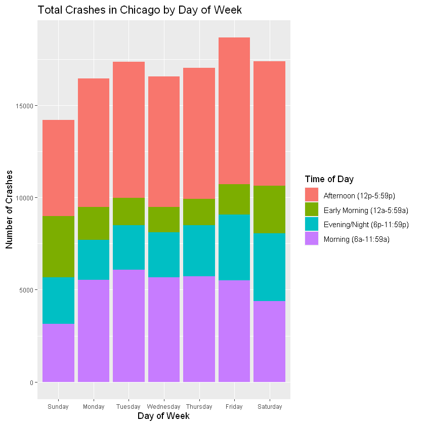

```r
#Crashes by day of week
by_day_of_week <- select(traffic, CRASH_DAY_OF_WEEK, CRASH_HOUR, PRIM_CONTRIBUTORY_CAUSE)
by_day_of_week$CRASH_DAY_OF_WEEK = factor(by_day_of_week$CRASH_DAY_OF_WEEK,
                                          labels = c("Sunday", "Monday", "Tuesday",
                                                     "Wednesday", "Thursday", "Friday", "Saturday"))
by_day_of_week <- mutate(by_day_of_week, CRASH_TIMEOFDAY = "")

#Set times of day
by_day_of_week$CRASH_TIMEOFDAY[by_day_of_week$CRASH_HOUR > 6 & by_day_of_week$CRASH_HOUR <= 12] = "Morning (6a-11:59a)"
by_day_of_week$CRASH_TIMEOFDAY[by_day_of_week$CRASH_HOUR >= 13 & by_day_of_week$CRASH_HOUR <= 18] = "Afternoon (12p-5:59p)"
by_day_of_week$CRASH_TIMEOFDAY[by_day_of_week$CRASH_HOUR >= 19] = "Evening/Night (6p-11:59p)"
by_day_of_week$CRASH_TIMEOFDAY[by_day_of_week$CRASH_HOUR <= 6] = "Early Morning (12a-5:59a)"

#plot
ggplot(by_day_of_week) + geom_bar(aes(x = CRASH_DAY_OF_WEEK, fill = CRASH_TIMEOFDAY)) +
labs(x = "Day of Week", y = "Number of Crashes", title = "Total Crashes in Chicago by Day of Week", fill = "Time of Day") +
theme(axis.text=element_text(size=7))


#table
table = group_by(by_day_of_week, CRASH_TIMEOFDAY, CRASH_DAY_OF_WEEK) %>%
summarize(n = n()) %>%
spread(CRASH_TIMEOFDAY, n) %>%
rename("Day of Week" = CRASH_DAY_OF_WEEK)
mutate(table, Total = table$"Morning (6a-11:59a)" + table$"Afternoon (12p-5:59p)" +
       table$"Evening/Night (6p-11:59p)" + table$"Early Morning (12a-5:59a)")
```

## What Is the Most Dangerous Season to Drive in Chicago?¶

One of the most counterintuitive conclusions of this analysis is the determination of the most dangerous and least dangerous seasons to drive. Winter weather is notoriously dangerous to drive in, especially in a city like Chicago, but as it turns out, fewer crashes occur in the winter in Chicago than any other season. In fact, there are over 13% fewer crashes in winter than there is in the summer. There are many factors that could be at play here, but this is probably mostly due to fewer people driving overall in the winter than in other seasons and more people adapting a cautious and careful driving style in the winter to avoid crashes.

A grouped_df: 4 × 2

| Season <chr> | Number of Accidents <int> |
| --- | --- |
| Fall | 29389 |
| Spring | 29900 |
| Summer | 31304 |
| Winter | 27155 |

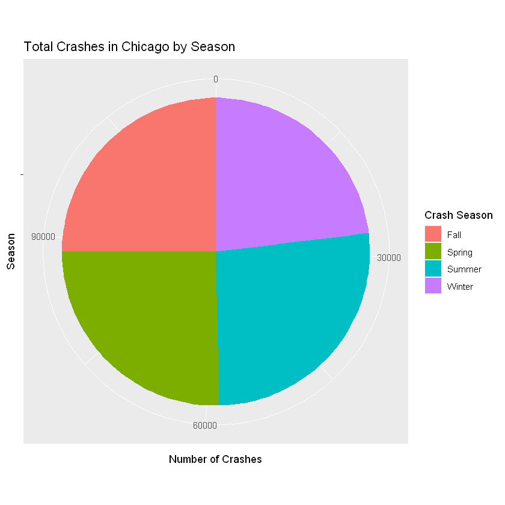

```r
#Crashes by season
rm(by_season)
by_season <- select(traffic, CRASH_MONTH, CRASH_HOUR, STREET_DIRECTION) %>%
mutate(CRASH_SEASON = "")

by_season$CRASH_SEASON[by_season$CRASH_MONTH > 5 & by_season$CRASH_MONTH <= 8] = "Summer"
by_season$CRASH_SEASON[by_season$CRASH_MONTH > 2 & by_season$CRASH_MONTH <= 5] = "Spring"
by_season$CRASH_SEASON[by_season$CRASH_MONTH > 8 & by_season$CRASH_MONTH <= 11] = "Fall"
by_season$CRASH_SEASON[by_season$CRASH_MONTH > 11 | by_season$CRASH_MONTH <= 2] = "Winter"

#plot
ggplot(by_season) + geom_bar(aes(x = "", fill = CRASH_SEASON)) + coord_polar("y", start=0)+
labs(x = "Season", y = "Number of Crashes", title = "Total Crashes in Chicago by Season", fill = "Crash Season")

#table
totals = group_by(by_season, CRASH_SEASON) %>%
summarize(CRASH_SEASON, n = n()) %>% unique  %>% rename("Season" = CRASH_SEASON) %>% rename("Number of Accidents" = n)
totals
```

## Is It More Dangerous to Drive With the Sun in Your Eyes in Chicago?¶

Intuitively, there would be a higher risk of an accident when facing the sun during sunrise/sunset than when facing away from it as visibility is reduced. We run a binomial test that compares whether an accident involved someone driving with the sun in their eyes by using the `STREET_DIRECTION` and `CRASH_HOUR` variables, with the season and sunrise/sunset times in Chicago. The test only considers accidents in the 2 hours after sunrise and before sunset and only those occurring on East/West Roads. As our p-value is $2.2 \cdot 10^{-16} < 0.05$, we reject the null hypothesis and accept that there is a statistically significant difference between the probability of an accident when drivers have the sun in their eyes and the same probability when drivers do not have the sun in their eyes.

As shown by the bar chart, there is a much higher chance of an accident on an E/W road to be caused by a driver with the sun in their eyes than one without the sun in their eyes. In fact, over 30% more crashes in 2019 on E/W roads around sunrise and sunset were caused by a driver facing the sun. Another noteworthy trend is that the difference is even more pronounced during the summer months, with nearly double the amount of crashes being caused by a driver facing the sun. The difference was most muted in the winter and spring, both of which showed only about a 14% difference. These trends make sense as the weather in summer and fall is generally clearer than in the winter/spring, so the sun is more likely to have an impact on visibility.

```
	Exact binomial test

data:  nrow(filter(sunriseset, sun_in_eyes == TRUE)) and nrow(sunriseset)
number of successes = 5031, number of trials = 8881, p-value < 2.2e-16
alternative hypothesis: true probability of success is not equal to 0.5
99 percent confidence interval:
 0.5528560 0.5800529
sample estimates:
probability of success
             0.5664903
```

A tibble: 4 × 3

| Season <chr> | FALSE <int> | TRUE <int> |
| --- | --- | --- |
| Fall | 735 | 939 |
| Spring | 1048 | 1196 |
| Summer | 694 | 1322 |
| Winter | 1373 | 1574 |

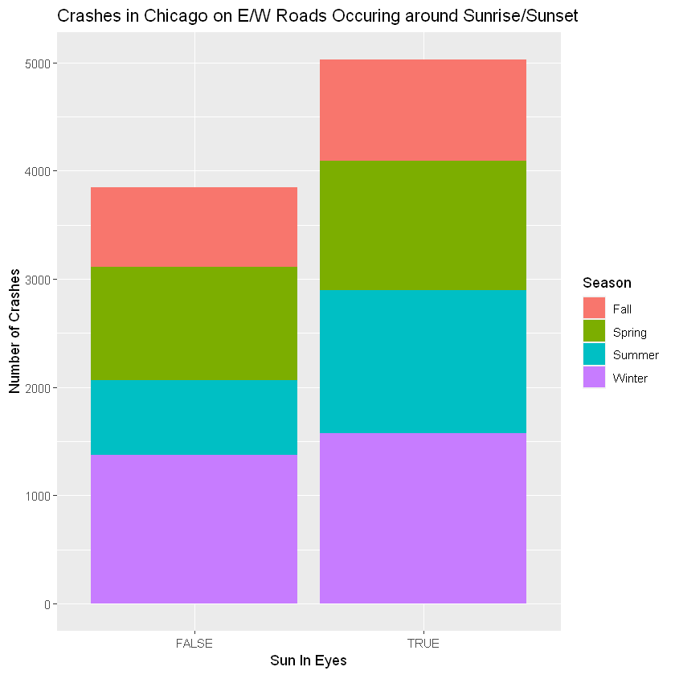

```r
#this graph takes all crashes that occurred during sunrise/sunset and determines if there were significantly more that occurred for drivers with sun in their eyes
sunriseset <- mutate(by_season, sun_in_eyes = NA)
#summer
sunriseset$sun_in_eyes[(sunriseset$STREET_DIRECTION == "E")
                       & sunriseset$CRASH_SEASON == "Summer" &
                      sunriseset$CRASH_HOUR <=6 & sunriseset$CRASH_HOUR >= 5] = TRUE
sunriseset$sun_in_eyes[(sunriseset$STREET_DIRECTION == "W")
                       & sunriseset$CRASH_SEASON == "Summer" &
                      sunriseset$CRASH_HOUR <=6 & sunriseset$CRASH_HOUR >= 5] = FALSE
sunriseset$sun_in_eyes[(sunriseset$STREET_DIRECTION == "E")
                       & sunriseset$CRASH_SEASON == "Summer" &
                      sunriseset$CRASH_HOUR <=19 & sunriseset$CRASH_HOUR >= 18] = FALSE
sunriseset$sun_in_eyes[(sunriseset$STREET_DIRECTION == "W")
                       & sunriseset$CRASH_SEASON == "Summer" &
                      sunriseset$CRASH_HOUR <=19 & sunriseset$CRASH_HOUR >= 18] = TRUE
#winter
sunriseset$sun_in_eyes[(sunriseset$STREET_DIRECTION == "E")
                       & (sunriseset$CRASH_SEASON == "Winter" | sunriseset$CRASH_MONTH == 11 | sunriseset$CRASH_MONTH == 2) &
                      sunriseset$CRASH_HOUR <= 8 & sunriseset$CRASH_HOUR >= 7] = TRUE
sunriseset$sun_in_eyes[(sunriseset$STREET_DIRECTION == "W")
                       & sunriseset$CRASH_SEASON == "Winter" &
                      sunriseset$CRASH_HOUR <=8 & sunriseset$CRASH_HOUR >= 7] = FALSE
sunriseset$sun_in_eyes[(sunriseset$STREET_DIRECTION == "E")
                       & sunriseset$CRASH_SEASON == "Winter" &
                      sunriseset$CRASH_HOUR <=16 & sunriseset$CRASH_HOUR >= 15] = FALSE
sunriseset$sun_in_eyes[(sunriseset$STREET_DIRECTION == "W")
                       & sunriseset$CRASH_SEASON == "Winter" &
                      sunriseset$CRASH_HOUR <=16 & sunriseset$CRASH_HOUR >= 15] = TRUE

#spring/fall
sunriseset$sun_in_eyes[(sunriseset$STREET_DIRECTION == "E")
                       & ((sunriseset$CRASH_MONTH >=3 & sunriseset$CRASH_MONTH <=5) |
                          (sunriseset$CRASH_MONTH == 9 | sunriseset$CRASH_MONTH == 10)) &
                      sunriseset$CRASH_HOUR <= 7 & sunriseset$CRASH_HOUR >= 6] = TRUE
sunriseset$sun_in_eyes[(sunriseset$STREET_DIRECTION == "W")
                       & ((sunriseset$CRASH_MONTH >=3 & sunriseset$CRASH_MONTH <=5) |
                          (sunriseset$CRASH_MONTH == 9 | sunriseset$CRASH_MONTH == 10)) &
                      sunriseset$CRASH_HOUR <= 7 & sunriseset$CRASH_HOUR >= 6] = FALSE
sunriseset$sun_in_eyes[(sunriseset$STREET_DIRECTION == "E")
                       & ((sunriseset$CRASH_MONTH >=3 & sunriseset$CRASH_MONTH <=5) |
                          (sunriseset$CRASH_MONTH == 9 | sunriseset$CRASH_MONTH == 10)) &
                      sunriseset$CRASH_HOUR <=19 & sunriseset$CRASH_HOUR >= 18] = FALSE
sunriseset$sun_in_eyes[(sunriseset$STREET_DIRECTION == "W")
                       & ((sunriseset$CRASH_MONTH >=3 & sunriseset$CRASH_MONTH <=5) |
                          (sunriseset$CRASH_MONTH == 9 | sunriseset$CRASH_MONTH == 10)) &
                      sunriseset$CRASH_HOUR <= 19 & sunriseset$CRASH_HOUR >= 18] = TRUE

#binomial test to see if a statistically significant difference exists
sunriseset <- filter(sunriseset, !is.na(sun_in_eyes))
binom.test(nrow(filter(sunriseset, sun_in_eyes == TRUE)),nrow(sunriseset),
           p = 0.5, alternative = "two.sided", conf.level = 0.99)

#plot
ggplot(sunriseset) + geom_bar(aes(x = sun_in_eyes, fill = CRASH_SEASON)) +
labs(x = "Sun In Eyes", y = "Number of Crashes",
     title = "Crashes in Chicago on E/W Roads Occuring around Sunrise/Sunset", fill = "Season")

#table
table = group_by(sunriseset, sun_in_eyes, CRASH_SEASON) %>%
summarize(n = n()) %>%
spread(sun_in_eyes, n) %>%
rename("Season" = CRASH_SEASON)

table
```

## Is It More Dangerous to Drive During the Holidays in Chicago?

This section compares crash data from some of the most popular U.S. holidays, including New Year's, St. Patrick's Day, Memorial Day, Independence Day, Labor Day, Thanksgiving, and Christmas. Elements of `CRASH_DATE` are converted to date objects on the fly.

A grouped_df: 8 × 5

| holiday <fct> | Other <dbl> | Street <dbl> | Intersection <dbl> | Highway <dbl> |
| --- | --- | --- | --- | --- |
| Christmas | 32.33333 | 171.3333 | 32.33333 | 66.66667 |
| Independence Day | 36.75000 | 173.0000 | 23.25000 | 62.50000 |
| Labor Day | 34.25000 | 170.5000 | 22.25000 | 58.50000 |
| Memorial Day | 31.50000 | 170.7500 | 26.25000 | 65.50000 |
| New Year's | 24.00000 | 195.0000 | 34.00000 | 76.00000 |
| None | 34.19048 | 195.1518 | 31.30342 | 73.42560 |
| St. Patrick's Day | 43.00000 | 219.3333 | NA | 79.66667 |
| Thanksgiving | 29.66667 | 162.0000 | 31.66667 | 64.50000 |

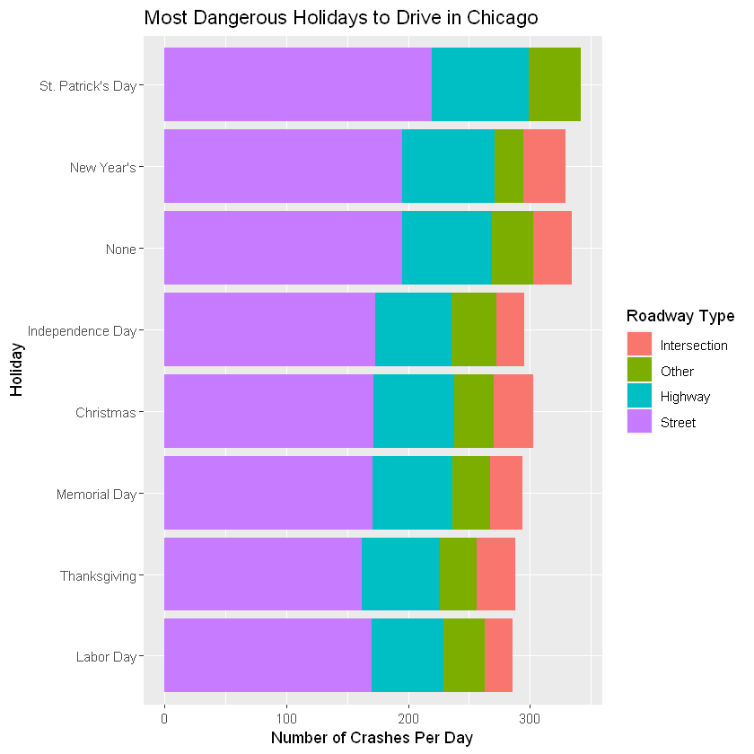

```r
#most dangerous holidays
chicago_holidays <- mutate(traffic, holiday = "None")
chicago_holidays$CRASH_DATE = substr(chicago_holidays$CRASH_DATE,1,10)

chicago_holidays <- filter(chicago_holidays, mdy(chicago_holidays$CRASH_DATE) >=
                           mdy("01/01/2019"), mdy(chicago_holidays$CRASH_DATE) <= mdy("12/31/2019"))
#New Year's
chicago_holidays$holiday[mdy(chicago_holidays$CRASH_DATE) == mdy("01/01/2019") |
                         mdy(chicago_holidays$CRASH_DATE) == mdy("12/31/2019")] = "New Year's"
#St. Patrick's Day
chicago_holidays$holiday[mdy(chicago_holidays$CRASH_DATE) >= mdy("03/15/2019") &
                         mdy(chicago_holidays$CRASH_DATE) <= mdy("03/17/2019")] = "St. Patrick's Day"
#Memorial Day
chicago_holidays$holiday[mdy(chicago_holidays$CRASH_DATE) >= mdy("05/24/2019") &
                         mdy(chicago_holidays$CRASH_DATE) <= mdy("05/27/2019")] = "Memorial Day"
#Independence Day
chicago_holidays$holiday[mdy(chicago_holidays$CRASH_DATE) >= mdy("07/04/2019") &
                         mdy(chicago_holidays$CRASH_DATE) <= mdy("07/07/2019")] = "Independence Day"
#Labor Day
chicago_holidays$holiday[mdy(chicago_holidays$CRASH_DATE) >= mdy("08/30/2019") &
                         mdy(chicago_holidays$CRASH_DATE) <= mdy("09/02/2019")] = "Labor Day"
#Thanksgiving
chicago_holidays$holiday[mdy(chicago_holidays$CRASH_DATE) >= mdy("11/22/2019") &
                         mdy(chicago_holidays$CRASH_DATE) <= mdy("11/24/2019")
                         | (mdy(chicago_holidays$CRASH_DATE) >= mdy("11/29/2019") &
                            mdy(chicago_holidays$CRASH_DATE) <= mdy("12/01/2019"))] = "Thanksgiving"
#Christmas
chicago_holidays$holiday[mdy(chicago_holidays$CRASH_DATE) >= mdy("12/20/2019") &
                         mdy(chicago_holidays$CRASH_DATE) <= mdy("12/22/2019")
                         | (mdy(chicago_holidays$CRASH_DATE) >= mdy("12/27/2019") &
                            mdy(chicago_holidays$CRASH_DATE) <= mdy("12/29/2019"))] = "Christmas"

#Set TRAFFICWAY_TYPE to more general factors
chicago_holidays$TRAFFICWAY_TYPE[chicago_holidays$TRAFFICWAY_TYPE == "ROUNDABOUT" |
                                 chicago_holidays$TRAFFICWAY_TYPE == "Y-INTERSECTION" |
                                 chicago_holidays$TRAFFICWAY_TYPE == "FIVE POINT, OR MORE" |
                                 chicago_holidays$TRAFFICWAY_TYPE == "FOUR WAY" |
                                 chicago_holidays$TRAFFICWAY_TYPE == "L-INTERSECTION" |
                                 chicago_holidays$TRAFFICWAY_TYPE == "T-INTERSECTION" |
                                 chicago_holidays$TRAFFICWAY_TYPE == "UNKNOWN INTERSECTION TYPE"] = "Intersection"
chicago_holidays$TRAFFICWAY_TYPE[chicago_holidays$TRAFFICWAY_TYPE == "RAMP" |
                                 chicago_holidays$TRAFFICWAY_TYPE == "DIVIDED - W/MEDIAN (NOT RAISED)" |
                                 chicago_holidays$TRAFFICWAY_TYPE == "DIVIDED - W/MEDIAN BARRIER" |
                                 chicago_holidays$TRAFFICWAY_TYPE == "TRAFFIC ROUTE"] = "Highway"
chicago_holidays$TRAFFICWAY_TYPE[chicago_holidays$TRAFFICWAY_TYPE == "ALLEY" |
                                 chicago_holidays$TRAFFICWAY_TYPE == "CENTER TURN LANE" |
                                 chicago_holidays$TRAFFICWAY_TYPE == "DRIVEWAY" |
                                 chicago_holidays$TRAFFICWAY_TYPE == "NOT DIVIDED" |
                                 chicago_holidays$TRAFFICWAY_TYPE == "ONE-WAY"] = "Street"
chicago_holidays$TRAFFICWAY_TYPE[chicago_holidays$TRAFFICWAY_TYPE == "NOT REPORTED" |
                                 chicago_holidays$TRAFFICWAY_TYPE == "OTHER" |
                                 chicago_holidays$TRAFFICWAY_TYPE == "UNKNOWN" |
                                 chicago_holidays$TRAFFICWAY_TYPE == "PARKING LOT"] = "Other"

#reorder TRAFFICWAY_TYPE factors
chicago_holidays$TRAFFICWAY_TYPE = factor(chicago_holidays$TRAFFICWAY_TYPE,
                                          levels = c("Other", "Street", "Intersection", "Highway"))
levels(chicago_holidays$TRAFFICWAY_TYPE) = reorder(levels(chicago_holidays$TRAFFICWAY_TYPE), c(4,3,1,2))

#finalize data summary
chicago_holidays <- select(chicago_holidays, CRASH_DATE, holiday, TRAFFICWAY_TYPE) %>%
group_by(holiday, TRAFFICWAY_TYPE,  mdy(CRASH_DATE)) %>%
summarize(n = n(), TRAFFICWAY_TYPE) %>%
unique%>%
group_by(holiday, TRAFFICWAY_TYPE) %>%
summarize(n = sum(n), days = n()) %>%
unique %>%
summarize(holiday, n, days, per_day = n/days, TRAFFICWAY_TYPE) %>% arrange(desc(per_day))

#convert holiday to a factor variable
chicago_holidays$holiday = factor(chicago_holidays$holiday)

#construct plot
ggplot(chicago_holidays) + geom_bar(aes(y = fct_reorder(holiday, per_day), x = per_day,
                                        fill = fct_reorder(TRAFFICWAY_TYPE, per_day)), stat = "identity") +
labs(x = "Number of Crashes Per Day", y = "Holiday",
     title = "Most Dangerous Holidays to Drive in Chicago", fill = "Roadway Type")

#table
table = select(chicago_holidays, -n, -days) %>%
spread(TRAFFICWAY_TYPE, per_day)

table
```

## Conclusion on Most Dangerous Times to Drive

In terms of the most dangerous times to drive, many of the findings confirmed intuition, such as the worst times of day and days of the week. Some of the conclusions were rather shocking, however, such as the notion that the winter is in fact the least dangerous season and summer is the most dangerous in terms of crash count. Results like these were especially interesting and led to captivating discussions regarding the potential causes behind the data.

# Question 3: What Are the Most Dangerous Conditions to Drive In?

To prepare the data for analysis, all variables except the ones listed as used in this question earlier in this report, were filtered out. All `NA`’s in these variables were also removed as they would not meaningfully contribute to the analysis.

## What Are the Most Dangerous Weather Conditions to Drive In?

```
# A tibble: 11 x 3
   WEATHER_CONDITION      Count Percent
   <chr>                  <int>   <dbl>
 1 CLEAR                  91594 46.3
 2 RAIN                   11304  5.72
 3 UNKNOWN                 4944  2.50
 4 SNOW                    4892  2.47
 5 CLOUDY/OVERCAST         3885  1.96
 6 OTHER                    441  0.223
 7 SLEET/HAIL               269  0.136
 8 FREEZING RAIN/DRIZZLE    202  0.102
 9 FOG/SMOKE/HAZE           157  0.0794
10 SEVERE CROSS WIND GATE    35  0.0177
11 BLOWING SNOW              25  0.0126
```

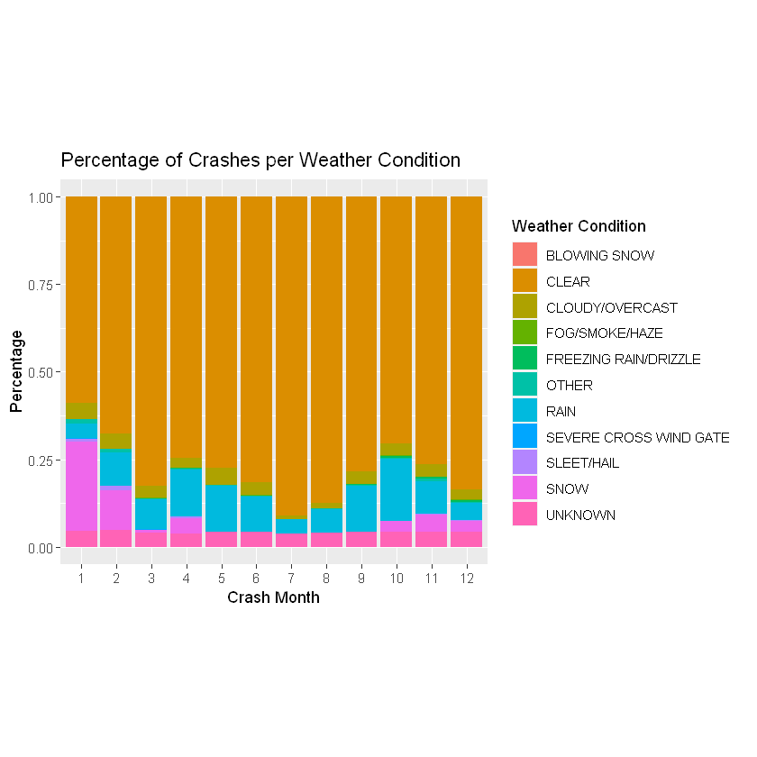

```r
#Count and percentages of crashes per weather condition: Table+Graph
weather<- traffic %>% select(WEATHER_CONDITION, CRASH_MONTH) %>%
group_by(WEATHER_CONDITION) %>%
summarise(Count=n(), Percent= (Count/197710)*100)%>%
arrange(desc(Percent))
print(weather)

ggplot(data = traffic) +
 geom_bar(mapping = aes(x = as.factor(CRASH_MONTH), fill = WEATHER_CONDITION), position = "fill") +
 labs(title = "Percentage of Crashes per Weather Condition", x= "Crash Month", y= "Percentage",
      fill="Weather Condition") + coord_fixed(10)
```

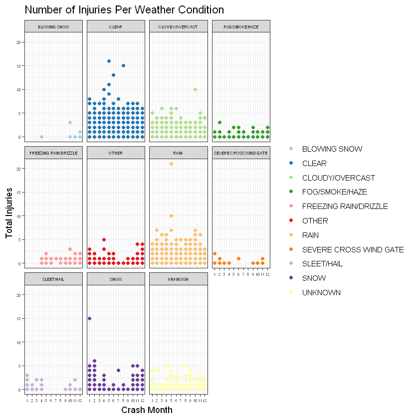

```r
options(jupyter.plot_scale=1)

ggplot(traffic, aes(CRASH_MONTH, INJURIES_TOTAL)) + geom_point(aes(color = WEATHER_CONDITION)) +
 scale_x_continuous("Crash Month", breaks = seq(0,12,1))+
 scale_y_continuous("Total Injuries", breaks = seq(0,25,by = 5))+
 theme_bw() + labs(title="Number of Injuries Per Weather Condition") + facet_wrap( ~ WEATHER_CONDITION) +
 theme(strip.text.x = element_text(size = 5), axis.text=element_text(size=5))+
     scale_color_brewer(name="", palette='Paired')

options(jupyter.plot_scale=1.5)
```

These results support the findings from the earlier section, where more crashes occurred during the summer than the winter. There are multiple different explanations for these results. For one, there might just be a higher number of clear days all around the year, which would mean that there would be more crashes that happened to occur on such days, rather than be caused by it. Secondly, there might be more crashes during clear days rather than snowy or rainy days since individuals might be more careful while driving during the latter days. This inherent caution might indicate why more crashes, and more dangerous crashes, occur during clear days. Drivers are less cautious of natural factors, so they might drive at a higher speed and not be as mindful of their driving as they should be. In the future, it will be important to find accurate weather calculations from official Chicago sources, which would provide how many days in a year are clear, cloudy, rainy, and the like. This way, each condition can be weighted appropriately according to their frequency in a year, and there would be more understanding as to whether the crashes just happened to occur during the weather condition that is most frequent, or as a result of said weather condition.

## What Are the Most Dangerous Lighting Conditions to Drive In?

A tibble: 6 × 3

| LIGHTING_CONDITION <chr> | Count <int> | Percent <dbl> |
| --- | --- | --- |
| DAYLIGHT | 77226 | 39.060240 |
| DARKNESS, LIGHTED ROAD | 24977 | 12.633150 |
| DARKNESS | 5736 | 2.901219 |
| UNKNOWN | 4131 | 2.089424 |
| DUSK | 3556 | 1.798594 |
| DAWN | 2122 | 1.073289 |

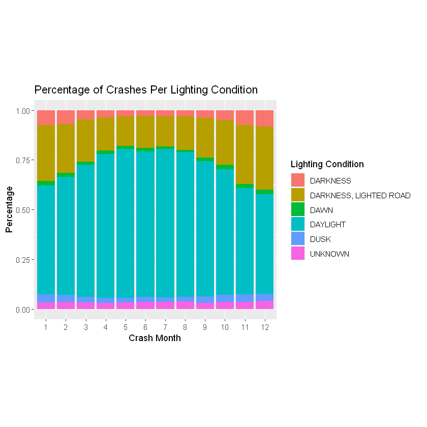

```r
#Count and percentages of crashes per lighting condition: Table+Graph
lighting<- traffic %>% select(LIGHTING_CONDITION, INJURIES_TOTAL) %>%
group_by(LIGHTING_CONDITION) %>%
summarise(Count=n(), Percent= (Count/197710)*100) %>%
arrange(desc(Percent))
lighting

ggplot(data = traffic) +
 geom_bar(mapping = aes(x = as.factor(CRASH_MONTH), fill = LIGHTING_CONDITION), position = "fill") +
 labs(title = "Percentage of Crashes Per Lighting Condition", fill = "Lighting Condition",
      x= "Crash Month", y= "Percentage")+ coord_fixed(10)
```

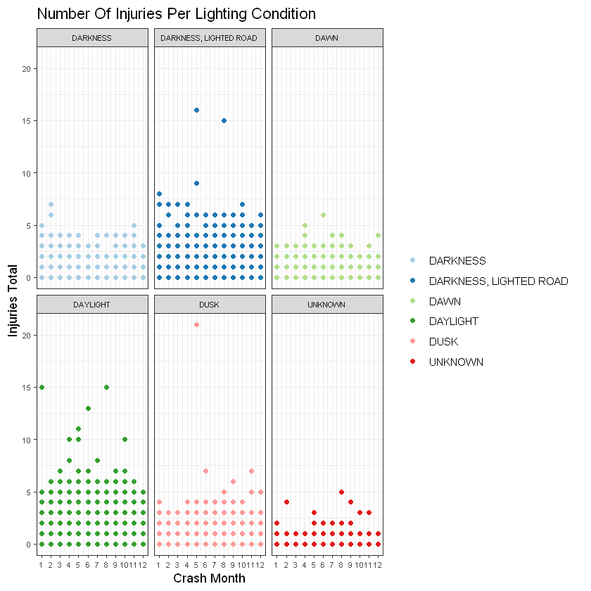

```r
options(jupyter.plot_scale=1.3)

ggplot(traffic, aes(CRASH_MONTH, INJURIES_TOTAL)) + geom_point(aes(color = LIGHTING_CONDITION)) +
 scale_x_continuous("Crash Month", breaks = seq(0,12,1))+
 scale_y_continuous("Injuries Total", breaks = seq(0,25,by = 5))+
 theme_bw() + labs(title="Number Of Injuries Per Lighting Condition", fill = "Lighting Condition") +
facet_wrap( ~ LIGHTING_CONDITION) +
 theme(strip.text.x = element_text(size = 6.5), axis.text=element_text(size=6.5))+
     scale_color_brewer(name="", palette='Paired')

options(jupyter.plot_scale=1.5)
```

## The Interaction Between Weather and Lighting Conditions

The graph below displays the interaction between the weather and lighting conditions to see if there is a possible relationship between the two variables. Corroborating the two previous questions, the highest number of crashes and the highest number of injuries happen with clear weather AND on daylight/lighted roads, signalling that the two conditions seem to have a relationship with each other.

Again, we temporarily modify the plot size to better display this visualization.

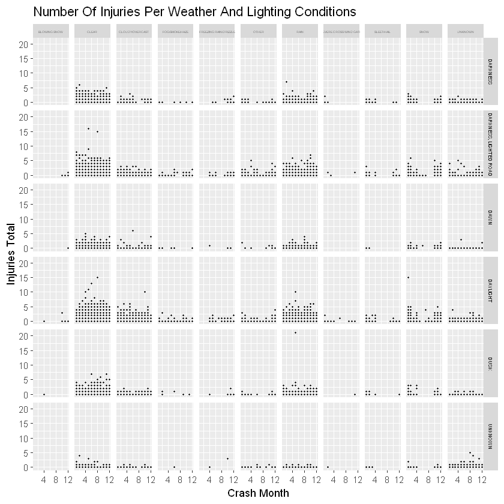

```r
options(jupyter.plot_scale=1)

traffic%>%
ggplot()+
 geom_point(mapping = aes(x = (CRASH_MONTH), y = INJURIES_TOTAL), size= 0.5) +
 facet_grid(LIGHTING_CONDITION~ WEATHER_CONDITION)+
 theme(strip.text.x = element_text(size = 3), strip.text.y= element_text(size=5))+
 scale_x_continuous("Crash Month", breaks = seq(0,12,4))+
 scale_y_continuous("Injuries Total", breaks = seq(0,25,by = 5))+
 labs(title="Number Of Injuries Per Weather And Lighting Conditions")

options(jupyter.plot_scale=1.5)
```

## What Are the Most Dangerous Road Conditions to Drive In?

```
# A tibble: 7 x 3
# Groups:   ROADWAY_SURFACE_COND [7]
  ROADWAY_SURFACE_COND Count Percent
  <chr>                <int>   <dbl>
1 DRY                  86118 43.6
2 WET                  17505  8.85
3 UNKNOWN               7648  3.87
4 SNOW OR SLUSH         4898  2.48
5 ICE                   1281  0.648
6 OTHER                  252  0.127
7 SAND, MUD, DIRT         46  0.0233
```

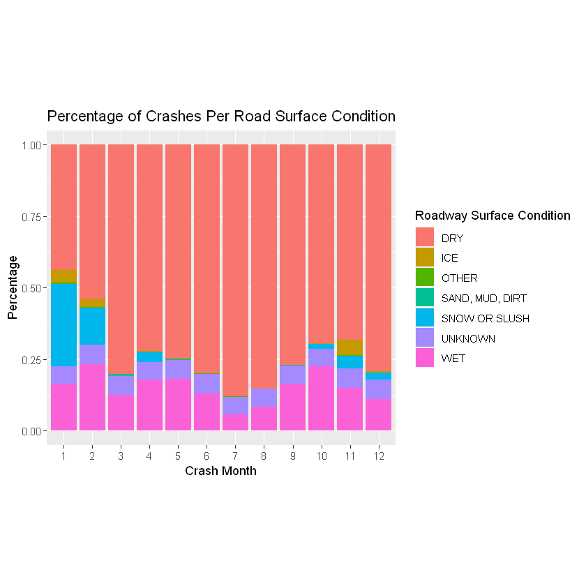

[output not shown]

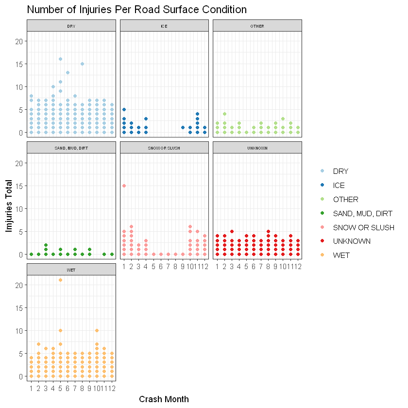

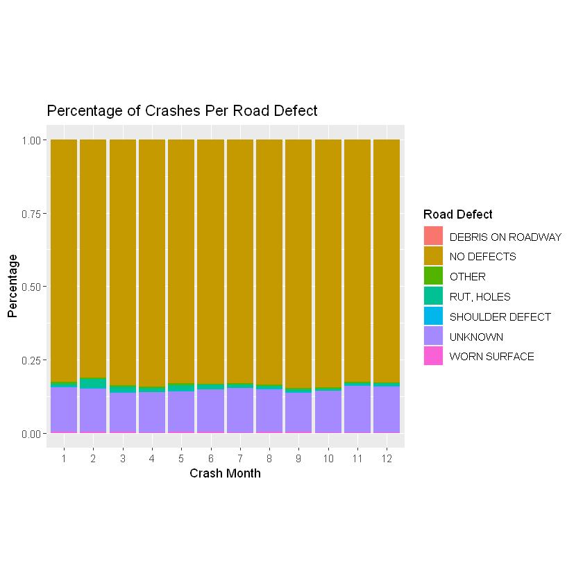

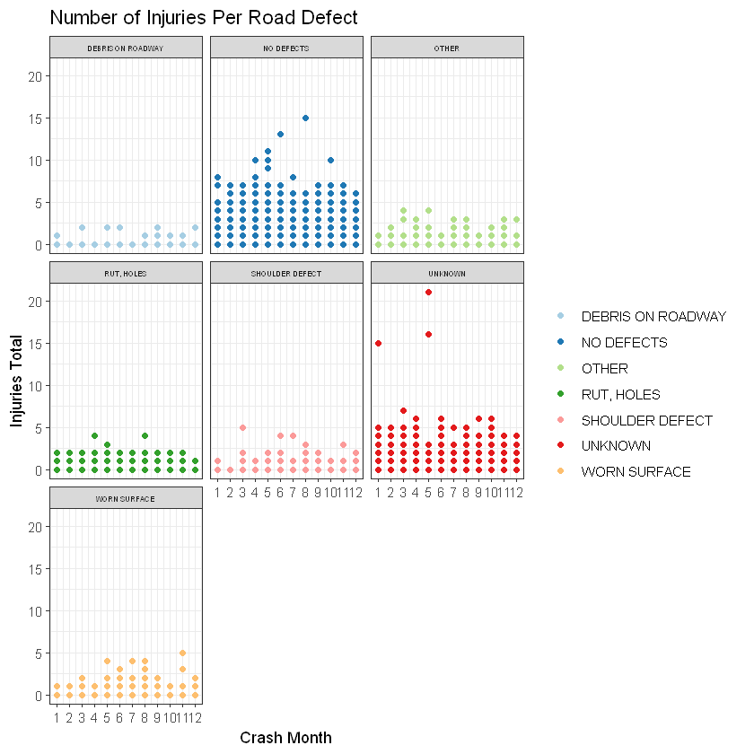

```r
roadsurface<- traffic %>% select(ROADWAY_SURFACE_COND, CRASH_MONTH) %>%
group_by(ROADWAY_SURFACE_COND) %>%
summarise(Count=n(), Percent= (Count/197710)*100, .groups="keep") %>%
arrange(desc(Percent))

print(roadsurface, digits=5)

ggplot(data = traffic) +
 geom_bar(mapping = aes(x = as.factor(CRASH_MONTH), fill = ROADWAY_SURFACE_COND), position = "fill") +
 labs(title = "Percentage of Crashes Per Road Surface Condition",
      x= "Crash Month", y= "Percentage", fill="Roadway Surface Condition")+ coord_fixed(10)

ggplot(traffic, aes(CRASH_MONTH, INJURIES_TOTAL)) + geom_point(aes(color = ROADWAY_SURFACE_COND)) +
 scale_x_continuous("Crash Month", breaks = seq(0,12,1))+
 scale_y_continuous("Imjuries Total", breaks = seq(0,25,by = 5))+
 theme_bw() + labs(title="Number of Injuries Per Road Surface Condition") +
facet_wrap( ~ ROADWAY_SURFACE_COND) +
 theme(strip.text.x = element_text(size = 5)) +
    scale_color_brewer(name="", palette='Paired')


roaddefect<- traffic %>% select(ROAD_DEFECT, CRASH_MONTH) %>%
group_by(ROAD_DEFECT) %>%
summarise(Count=n(), Percent= (Count/197710)*100, .groups="keep") %>%
arrange(desc(Percent))

print(roaddefect, digits=5)

ggplot(data = traffic) +
 geom_bar(mapping = aes(x = as.factor(CRASH_MONTH), fill = ROAD_DEFECT), position = "fill") +
 labs(title = "Percentage of Crashes Per Road Defect", x= "Crash Month",
      y= "Percentage", fill="Road Defect")+
coord_fixed(10)

traffic %>% filter(!is.na(INJURIES_TOTAL)) %>% ggplot( aes(CRASH_MONTH, INJURIES_TOTAL)) + geom_point(aes(color = ROAD_DEFECT)) +
 scale_x_continuous("Crash Month", breaks = seq(0,12,1))+
 scale_y_continuous("Injuries Total", breaks = seq(0,25,by = 5))+
 theme_bw() + labs(title="Number of Injuries Per Road Defect") +
facet_wrap( ~ ROAD_DEFECT) +
 theme(strip.text.x = element_text(size = 5)) +
     scale_color_brewer(name="", palette='Paired')
```

## The Interaction Between Road Surface Conditions and Road Defects

Again, we temporarily modify the plot size to better display this visualization.

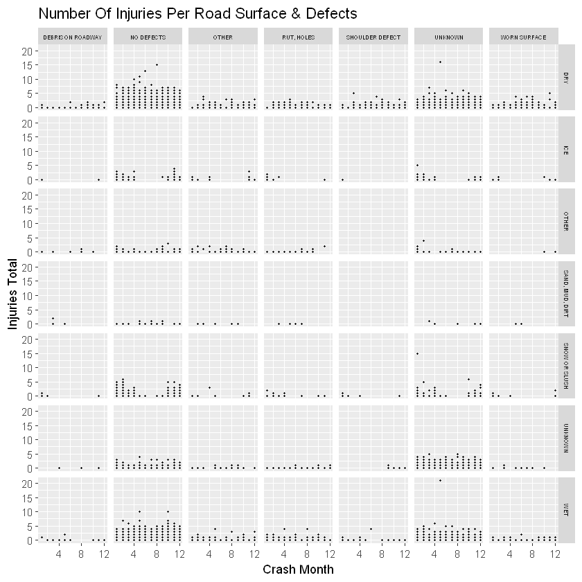

```r
options(jupyter.plot_scale=1)

traffic%>% filter(!is.na(INJURIES_TOTAL)) %>%
ggplot() +
 geom_point(mapping = aes(x = CRASH_MONTH, y = INJURIES_TOTAL), size= 0.5) +
 facet_grid(ROADWAY_SURFACE_COND~ ROAD_DEFECT) +
 theme(strip.text.x = element_text(size = 5), strip.text.y= element_text(size=5))+
 scale_x_continuous("Crash Month", breaks = seq(0,12,4))+
 scale_y_continuous("Injuries Total", breaks = seq(0,25,by = 5))+
 labs(title="Number Of Injuries Per Road Surface & Defects")

options(jupyter.plot_scale=1.5)
```

## Conclusion on Most Dangerous Conditions to Drive In

# Question 4: Where Are the Most Accident-Prone Areas of Chicago?

## Methodology

In exploring this question, we will take a spatial approach to answering it. Rather than organizing tibbles of street names and sorting them by street number, we will consider two types of crashes, (1) all accidents and (2) serious accidents where people were incapacitated or fatally injured, and:

1. Plot the two types of accidents on the map of Chicago, where each accident is represented by a point.
2. Plot density estimates of both types of accidents on the maps of Chicago and downtown Chicago to find hotspots.
3. Perform cluster analysis on incapacitated/fatal accidents with the DBSCAN algorithm, aggressively filtering out noise, to find clusters of the more severe crashes.

We filter our accidents according to latitude and longitude bounds to remove `NA` entries and entries where either latitude and longitude were equal to zero.

```r
### BEGIN SOLUTION

traffic = traffic %>% filter(!is.na(LATITUDE), !is.na(LONGITUDE),
                             LATITUDE>0, LONGITUDE<0)
traffic_injuries = traffic %>% filter((INJURIES_FATAL+INJURIES_INCAPACITATING) > 0, !is.na(INJURIES_FATAL))
traffic %>% head

downtown_traffic = traffic %>% filter(LATITUDE > 41.86, LATITUDE < 41.918,
                                    LONGITUDE > -87.66, LONGITUDE < -87.606)
downtown_injuries = traffic_injuries %>% filter(LATITUDE > 41.86, LATITUDE < 41.918,
                                    LONGITUDE > -87.66, LONGITUDE < -87.606)

print(c(left = min(traffic$LONGITUDE, na.rm=TRUE),
                                  bottom = min(traffic$LATITUDE, na.rm=TRUE),
                                  right = max(traffic$LONGITUDE, na.rm=TRUE),
                                  top = max(traffic$LATITUDE, na.rm=TRUE)))
```

A tibble: 6 × 40

| X1 <dbl> | CRASH_RECORD_ID <chr> | RD_NO <chr> | CRASH_DATE <chr> | POSTED_SPEED_LIMIT <dbl> | TRAFFIC_CONTROL_DEVICE <chr> | DEVICE_CONDITION <chr> | WEATHER_CONDITION <chr> | LIGHTING_CONDITION <chr> | FIRST_CRASH_TYPE <chr> | ... | INJURIES_NON_INCAPACITATING <dbl> | INJURIES_REPORTED_NOT_EVIDENT <dbl> | INJURIES_NO_INDICATION <dbl> | INJURIES_UNKNOWN <dbl> | CRASH_HOUR <dbl> | CRASH_DAY_OF_WEEK <dbl> | CRASH_MONTH <dbl> | LATITUDE <dbl> | LONGITUDE <dbl> | LOCATION <chr> |
| --- | --- | --- | --- | --- | --- | --- | --- | --- | --- | --- | --- | --- | --- | --- | --- | --- | --- | --- | --- | --- |
| 5 | 00e47f189660cd8ba1e85fc63061bf1d8465184393f134fb8251ed7896a4ba9ed7c984ab51a01f564d6f4133c6ef8493b1a369743a4a308d4392900a286e160f | JC194776 | 03/21/2019 10:50:00 PM | 30 | TRAFFIC SIGNAL | FUNCTIONING PROPERLY | CLEAR | DARKNESS, LIGHTED ROAD | TURNING | ... | 0 | 0 | 2 | 0 | 22 | 5 | 3 | 41.74180 | -87.74095 | POINT (-87.740953581987 41.741803598989) |
| 8 | 0211e1f766f3940dfa87375661d25b716655e908c320cc46910e8fa5fb1f1e6a9d4f714d21e8e401ec9e0a12190b6cd9f6dbc97d32d0c0fc966a02ae516e782f | JC301403 | 06/11/2019 08:40:00 AM | 30 | TRAFFIC SIGNAL | FUNCTIONING PROPERLY | CLEAR | DAYLIGHT | REAR END | ... | 0 | 0 | 3 | 0 | 8 | 3 | 6 | 41.79478 | -87.62383 | POINT (-87.623828038036 41.794778764028) |
| 15 | 046c0f96fdf5f7384e026821bb23fdd56d610dce11247b4cf7072f4e0308cdf5865ee8f31d71792ef005d864c064aae933213ef5e4e87a9bb2247ffe0f56f245 | JC128226 | 01/24/2019 06:45:00 AM | 30 | NO CONTROLS | NO CONTROLS | CLEAR | DARKNESS, LIGHTED ROAD | REAR END | ... | 0 | 0 | 2 | 0 | 6 | 5 | 1 | 41.79478 | -87.62383 | POINT (-87.623828038036 41.794778764028) |
| 17 | 0564e565ebda939c88d5da6d613ac5789b702cbff5b8744552f9930bd571995afb81a895dfd2bc8a23e6cca53f8fc6a9afbeb38591781281a3c37ceba5cbcbd5 | JC541936 | 12/10/2019 03:15:00 PM | 20 | TRAFFIC SIGNAL | FUNCTIONING PROPERLY | CLEAR | DAYLIGHT | PEDESTRIAN | ... | 0 | 0 | 2 | 0 | 15 | 3 | 12 | 41.95420 | -87.66919 | POINT (-87.669192620028 41.954196228965) |
| 20 | 06d11d0ac4bf97a43f93b78768b225c91ba0579939a4fc92ba3f426a1353607f52a8f8536eefb3a7a3e75f553d1e941841ce5b26890e986b06ad85a716fa3a2c | JC263263 | 05/14/2019 07:30:00 PM | 20 | PEDESTRIAN CROSSING SIGN | FUNCTIONING PROPERLY | CLEAR | DAYLIGHT | PEDESTRIAN | ... | 1 | 0 | 2 | 0 | 19 | 3 | 5 | 41.95068 | -87.64378 | POINT (-87.64378474303 41.950676838996) |
| 23 | 074f50577888fe85727b97fe0010aa708efe985ae1effdd2d03730c444e95bf795e54e0f7a2123d3c97b8fc80e7b822ce64fdcef7dd6f1b510a0856c7d8d669f | JC539018 | 12/08/2019 08:14:00 AM | 35 | TRAFFIC SIGNAL | FUNCTIONING PROPERLY | CLEAR | DAYLIGHT | SIDESWIPE SAME DIRECTION | ... | 0 | 0 | 2 | 0 | 8 | 1 | 12 | 41.75872 | -87.58559 | POINT (-87.585590902031 41.758723759994) |

```
     left    bottom     right       top
-87.93401  41.64467 -87.52459  42.02272
```

## Summary of Crash Counts

To get a better idea of the size of the dataset we are dealing with, we display, in the form of a table, a few important summary statistics about the amount of accidents we deal with, in each of the four categories we divide them into. We see that the proportion of serious accidents where people were injured/fatally injured is small (1.8%), and that when taking area into account, the proportion of accidents that occured in in downtown Chicago is very large (13.6%). We explore this further later on with density estimates.

```r
crash_count = count(traffic)[['n']]
injury_count = count(traffic_injuries)[['n']]
downtown_count = (traffic %>% filter(LATITUDE > 41.86, LATITUDE < 41.918,
                                    LONGITUDE > -87.66, LONGITUDE < -87.606) %>% count())[['n']]
downtown_injuries_count = (traffic_injuries %>% filter(LATITUDE > 41.86, LATITUDE < 41.918,
                                    LONGITUDE > -87.66, LONGITUDE < -87.606) %>% count())[['n']]

tibble(Situations = c("Total Accidents",
      "Total Injuries/Fatal Accidents",
      "Downtown Accidents",
      "Downtown Injuries/Fatal Accidents"),
       Counts = c(crash_count,injury_count,downtown_count,downtown_injuries_count))
```

A tibble: 4 × 2

| Situations <chr> | Counts <int> |
| --- | --- |
| Total Accidents | 116820 |
| Total Injuries/Fatal Accidents | 2103 |
| Downtown Accidents | 15938 |
| Downtown Injuries/Fatal Accidents | 230 |

## Accident Density Estimates

Maps of Chicago are obtained from the open source maps available from `Stamen`, and the `ggmap` package, an extension of `ggplot2` with the same interface, is used to visualize our data on top of these maps. Again, we change the plot size to better display our visualizations. We generate six plots:

1. Scatter plot of all accidents in Chicago
2. Scatter plot of all incapacitated/fatal accidents in Chicago
3. Density estimate of all accidents in Chicago
4. Density estimate of all incapacitated/fatal accidents in Chicago
5. Density estimate of all accidents in Downtown Chicago
6. Density estimate of all incapacitated/fatal accidents in Downtown Chicago

The package `ggpubr`, again based off `ggplot2`, is used to display the six plots together in a coherent way with the function `ggarrange`.

In doing so, by (3), we find that the density of all accidents in Chicago is concentrated around downtown, explaining why the proportion of accidents downtown is so high relative to its area.

When considering accidents where people were incapacitated or fatally injured in (4), however, we see two prominent density peaks, one large one downtown and a smaller one centered at the intersection of South Pulaski Road and West Madison Street. The peak downtown is to be expected, but the other, less so. We suspect that this is due to the presence of many amenities in the area, such as a grocery store, a public school, a library, the USPS, and the fact that this happens to be a "mini-downtown" and a popular shopping district in the West Side of Chicago. This will be explored further in a later subsection immediately after this one.

Zooming into Downtown Chicago yields interesting results. Within Downtown Chicago itself, in (5), we see two density peaks (of total accidents). These are centered around the intersections of North Lasalle Drive and East Ohio Street, and the intersection between North Rush Street and East Ohio Street. The former is of the busy River North neighborhood, and is much larger in area than the latter, right next to the Magnificent Mile. The latter is of particular interest, as it has a very high density of crashes in a very small area. We find that it is located at a busy junction sandwiched between the Marriott Hotel, a department store, a parking garage, and the Homewood Suites by Hilton, where one of the two roads is a one-way road.

Lastly, in (6), we find one density peak of accidents where people were incapacitated or fatally injured. The very peak itself is small, centered around North State Street and North Dearborn Street, intersecting with West Kinzie Street, though the high density of incapacited/fatal accidents persists throughout the River North, Magnificent Mile, and The Loop neighborhoods. Examining the very peak itself, we find that it is sandwiched between the Kinzie Hotel and the Museum of Broadcast Communications. Parallel parking, construction, and an area where vehicles park and turn into the road exist in this stretch, further exarcebating safety concerns. Incidentally, this is very close to Trump Tower, a large parking garage called Greenway Garage, and the House of Blues, among other landmarks and prominent buildings, which likely contributes to high accident density within the area.

All in all, we find that while Downtown Chicago is a huge hotspot for accidents, there are areas both within and outside it that have high densities of accidents. The analysis here sheds some light as to why some areas in Chicago have especially high accident densities, and why some of the density peaks occur over surprisingly small areas.

```
Warning message:
"Removed 7239 rows containing non-finite values (stat_density2d_filled)."
Warning message:
"Removed 146 rows containing non-finite values (stat_density2d_filled)."
```

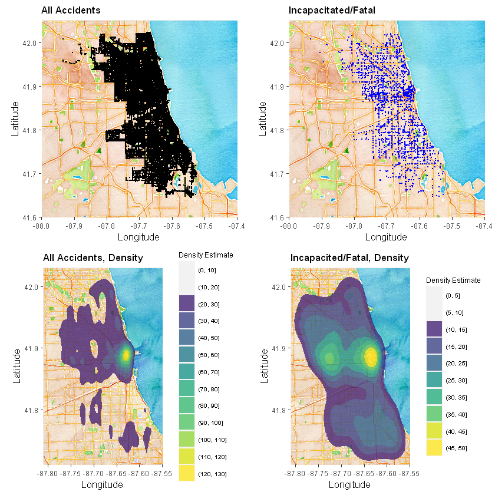

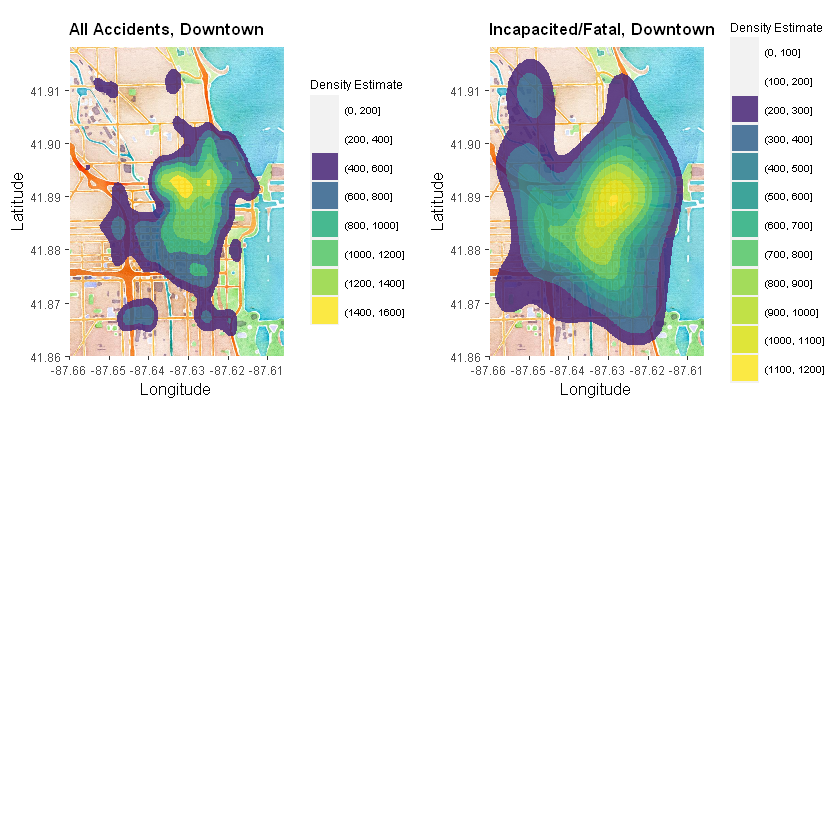

```r
options(jupyter.plot_scale=1)

chicago <- get_stamenmap(bbox = c(left = -88,
                                  bottom = 41.6,
                                  right = -87.4,
                                  top = 42.05),
                         zoom = 11, maptype="watercolor")

c1 = ggmap(chicago) + geom_point(data=traffic, aes(x = LONGITUDE , y = LATITUDE), size=0.01, color="black") +
ggtitle("All Accidents") + xlab("Longitude") + ylab("Latitude") +
theme(legend.position = "none", axis.text=element_text(size=7),
      axis.title=element_text(size=10), plot.title=element_text(size=10,face="bold"))

c2 = ggmap(chicago) + geom_point(data=traffic_injuries, aes(x = LONGITUDE , y = LATITUDE), size=0.01, color="blue") +
ggtitle("Incapacitated/Fatal") + xlab("Longitude") + ylab("Latitude") +
theme(legend.position = "none", axis.text=element_text(size=7),
      axis.title=element_text(size=10), plot.title=element_text(size=10,face="bold"))

chicago_zoom <- get_stamenmap(bbox = c(left = -87.81,
                                  bottom = 41.71,
                                  right = -87.55,
                                  top = 42.03),
                         zoom = 12, maptype="watercolor")
c5 = ggmap(chicago_zoom) + stat_density_2d_filled(data=traffic, aes(x = LONGITUDE , y = LATITUDE), alpha=0.8) +
  scale_fill_manual(values = c(NA, NA, "#482677FF", "#404788FF", "#33638DFF",
                                "#287D8EFF", "#1F968BFF",
                               "#29AF7FFF", "#3CBB75FF", "#55C667FF",
                               "#95D840FF", "#DCE319FF", "#FDE725FF")) +
xlab("Longitude") + ylab("Latitude") +
theme(legend.position = "right", legend.title = element_text(size=7),
      legend.text = element_text(size=6), axis.text=element_text(size=7),
      axis.title=element_text(size=10), plot.title=element_text(size=10,face="bold")) +
labs(fill = "Density Estimate") + ggtitle("All Accidents, Density")

c6 = ggmap(chicago_zoom) + stat_density_2d_filled(data=traffic_injuries, aes(x = LONGITUDE , y = LATITUDE), alpha=0.8) +
  scale_fill_manual(values = c(NA, NA, "#482677FF", "#404788FF", "#33638DFF",
                               "#1F968BFF",
                               "#29AF7FFF", "#55C667FF",
                               "#DCE319FF", "#FDE725FF")) +
xlab("Longitude") + ylab("Latitude") +
theme(legend.position = "right", legend.title = element_text(size=7),
      legend.text = element_text(size=6), axis.text=element_text(size=7),
      axis.title=element_text(size=10), plot.title=element_text(size=10,face="bold")) +
labs(fill = "Density Estimate") + ggtitle("Incapacited/Fatal, Density")

chicago_center <- get_stamenmap(bbox = c(left = -87.66,
                                  bottom = 41.86,
                                  right = -87.606,
                                  top = 41.918),
                         zoom = 14, maptype="watercolor")
c7 = ggmap(chicago_center) + stat_density_2d_filled(data=downtown_traffic, aes(x = LONGITUDE , y = LATITUDE), alpha=0.85) +
  scale_fill_manual(values = c(NA, NA, "#482677FF", "#33638DFF",
                               "#29AF7FFF", "#55C667FF",
                               "#95D840FF", "#FDE725FF")) +
xlab("Longitude") + ylab("Latitude") +
theme(legend.position = "right", legend.title = element_text(size=7),
      legend.text = element_text(size=6), axis.text=element_text(size=7),
      axis.title=element_text(size=10), plot.title=element_text(size=10,face="bold")) +
labs(fill = "Density Estimate") + ggtitle("All Accidents, Downtown")

c8 = ggmap(chicago_center) + stat_density_2d_filled(data=downtown_injuries, aes(x = LONGITUDE , y = LATITUDE), alpha=0.85) +
  scale_fill_manual(values = c(NA, NA, "#482677FF", "#33638DFF",
                              "#287D8EFF", "#1F968BFF",
                               "#29AF7FFF",  "#55C667FF",
                               "#95D840FF", "#B8DE29FF", "#DCE319FF", "#FDE725FF")) +
xlab("Longitude") + ylab("Latitude") +
theme(legend.position = "right", legend.title = element_text(size=7),
      legend.text = element_text(size=6), axis.text=element_text(size=7),
      axis.title=element_text(size=10), plot.title=element_text(size=10,face="bold")) +
labs(fill = "Density Estimate") + ggtitle("Incapacited/Fatal, Downtown")

f1 = ggarrange(c1,c2,c5,c6, ncol=2, nrow=2)
f2 = ggarrange(c7,c8,ncol=2, nrow=2)
f1
f2
```

### South Pulanski Road and West Madison Street

We further explore the curious case of the intersection between South Pulaski Road and West Madison Street being a lesser density peak of accidents were people were incapacitated or fatally injured. We look at accidents which occured in the area, grouping them by crash type and sorting according to how common each crash type was. It can be seen from the summary table below that the most common cause involved pedestrians, confirming our suspicions that increased foot traffic and potential jaywalking due to the area being a major shopping district was a contributory cause.

Accidents where vehicles crashed into each other at an angle and accidents where vehicles crashed due to turning are also relatively common. This may be due to increased traffic congestion in the area.

Lastly, parking accidents and rear-end collisions are also relatively common. We suspect that this is due to the parallel parking lots that are commonplace on this street.

```r
traffic %>% filter(LONGITUDE > -87.74, LONGITUDE < -87.71, LATITUDE > 41.86, LATITUDE < 41.89) %>%
select(FIRST_CRASH_TYPE, INJURIES_FATAL, INJURIES_INCAPACITATING) %>%
filter((INJURIES_FATAL+INJURIES_INCAPACITATING)>0) %>% mutate(Crash_Type = FIRST_CRASH_TYPE) %>%
group_by(Crash_Type) %>% summarize(Accidents = n()) %>% arrange(desc(Accidents))
```

A tibble: 12 × 2

| Crash_Type <chr> | Accidents <int> |
| --- | --- |
| PEDESTRIAN | 20 |
| ANGLE | 13 |
| PARKED MOTOR VEHICLE | 11 |
| TURNING | 9 |
| REAR END | 7 |
| FIXED OBJECT | 4 |
| HEAD ON | 4 |
| PEDALCYCLIST | 3 |
| SIDESWIPE SAME DIRECTION | 2 |
| OTHER OBJECT | 1 |
| REAR TO FRONT | 1 |
| SIDESWIPE OPPOSITE DIRECTION | 1 |

## Cluster Analysis of Incapacitated/Fatal Accidents in Chicago

The plot for the density of incapacitated/fatal accidents in Chicago is noteworthy, in that there are two prominent density peaks and a smaller, very much less prominent, third peak. To obtain a better idea of what's going on within this, we perform density-based clustering on incapacitated/fatal accidents in Chicago with the DBSCAN algorithm. The key idea behind this algorithm is clustering nearby points in areas of high-enough density.

Briefly, according to [Scikit-Learn](https://scikit-learn.org/stable/modules/clustering.html), for each data point $A$, expand the cluster containing it through assigning all other unclassified points to the cluster if they is within a certain distance $\epsilon$ from it, and there are greater than $minPts$ points within $\epsilon$ from $A$. Recursively, do the same for every point $B$ added to the first-level cluster with $A$, and every data point added to the second-level cluster with $B$, and so on.

In our use-case, it has the relevant strengths of allowing clusters of any shape, with potentially uneven sizes, and classifies points in areas of low density as noise.

We run DBSCAN with $\epsilon = 0.01$, and $minPts = 20$, as aggressive settings for both to filter out noise aggressively and to ensure that clusters that form aren't too large or too small.

### More Details on the Clusters Obtained

The clustering we performed was very aggressive in filtering out noise. Out of 2103 locations of incapacitated/fatal accidents, 1076 were filtered out as "noise". The three largest clusters contain 322, 193, and 79 accidents respectively.

### Visualization and Analysis of the Results Returned by DBSCAN

We visualize our clusters on the map of Chicago. Doing so reveals a large cluster of 322 accidents downtown, as expected, another large cluster of 193 accidents centered around South Pulanski Road and West Madison Street, as previously discussed. However, this reveals new information, reminding us that the area just north of the latter cluster, bounded between the Kennedy and Eisenhower expressways, is also very accident-prone. It also reminds us that there is another smaller, very much less prominent, hotspot south of Downtown Chicago, near the intersection between the Dan Ryan expressway and the Chicago Skyway, which contains the third-largest cluster of 79 accidents. Lastly, we find that there are two small clusters of 33 and 24 accidents along the coast north of downtown, and that there are accident hotspots located along the coast in general.

The roads most responsible for this are the roads along the coast, the Eisenhower expressway, the Dan Ryan expressway and the Chicago Skyway.

In general, summarizing the findings here, the crash hotspots in Chicago are:

1. Downtown
2. Between the Kennedy and Stevenson expressways (including the S Pulanski/W Madison cluster)
3. Near the intersection between the Dan Ryan expressway and the Chicago Skyway
4. Along the coast

This lines up with the density plot of all accidents in Chicago shown earlier, with significant densities of accidents occuring in exactly these areas. However, with total accidents, there is a larger disparity between the density of accidents downtown and the densities of accidents elsewhere.

```
DBSCAN clustering for 2103 objects.
Parameters: eps = 0.01, minPts = 20
The clustering contains 15 cluster(s) and 1076 noise points.

   0    1    2    3    4    5    6    7    8    9   10   11   12   13   14   15
1076  322  193   79   25   50   46   53   79   25   24   24   30   20   33   24

Available fields: cluster, eps, minPts
```

A tibble: 16 × 2

| Cluster <fct> | Count <int> |
| --- | --- |
| 1 | 322 |
| 2 | 193 |
| 3 | 79 |
| 4 | 25 |
| 5 | 50 |
| 6 | 46 |
| 7 | 53 |
| 8 | 79 |
| 9 | 25 |
| 10 | 24 |
| 11 | 24 |
| 12 | 30 |
| 13 | 20 |
| 14 | 33 |
| 15 | 24 |
| Noise | 1076 |

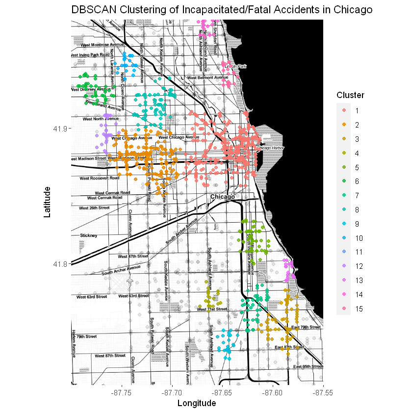

```r
chicago_zoom_toner <- get_stamenmap(bbox = c(left = -87.8,
                                  bottom = 41.71,
                                  right = -87.55,
                                  top = 41.98),
                         zoom = 12, maptype="toner")

clusters = dbscan(traffic_injuries %>% select(LATITUDE, LONGITUDE), eps=0.01, minPts = 20)

lev = c('1','2','3','4','5','6','7','8','9','10','11','12','13','14','15', "Noise")
clusters
as_tibble(clusters$cluster) %>% mutate(Cluster = factor(ifelse(value==0, "Noise", value),levels = lev)) %>%
group_by(Cluster) %>% summarize(Count = n())

traffic_injuries = traffic_injuries %>% mutate(cluster = clusters$cluster)
Cluster = as.factor((traffic_injuries %>% filter(cluster>0))$cluster)

ggmap(chicago_zoom_toner) +
geom_point(data=traffic_injuries %>% filter(cluster==0), aes(x = LONGITUDE , y = LATITUDE), alpha=0.1) +
geom_point(data=traffic_injuries %>% filter(cluster>0),
           aes(x = LONGITUDE , y = LATITUDE, color=Cluster), alpha=0.8) +
xlab("Longitude") + ylab("Latitude") + ggtitle("DBSCAN Clustering of Incapacitated/Fatal Accidents in Chicago")
```

## Conclusion on the Most Accident-Prone Areas in Chicago

There are significant densities of accidents occuring downtown, the area bounded by the Stevenson and Kennedy expressways, near the intersection between the Dan Ryan expressway and the Chicago Skyway, and along the coast, in both the cases where we consider total accidents and serious accidents where someone was incapacitated or fatally injured.

We find that regarding all total accidents, Downtown Chicago is the largest hotspot for accidents, with a large differential between the density in it and the density everywhere else. The two most accident-prone areas within Downtown Chicago were the busy River North neighborhood and a small spot right next to the Magnificent Mile.

Regarding more severe accidents where someone was incapacitated or fatally injured, Downtown Chicago is still the largest hotspot for accidents, with the second-largest hotspot alongside the Eisenhower expressway, centered at a busy shopping district. Other hotspots are located in the area bounded by the Stevenson and Kennedy expressways, near the intersection between the Dan Ryan expressway and the Chicago Skyway, and along the coast. The area in Downtown Chicago with the highest density of serious accidents is located nearby Trump Tower and centered around North State Street and North Dearborn Street, intersecting with West Kinzie Street, though the high density of incapacited/fatal accidents persists throughout the River North, Magnificent Mile, and The Loop neighborhoods.

Roads-wise, the roads along the coast, the Eisenhower expressway, the Dan Ryan expressway and the Chicago Skyway are roads where many serious accidents, where people are incapacitated or fatally injured, happen nearby.

# Conclusion

The Chicago Police Department collects crash data on city streets within the Chicago city limits and within the department’s jurisdiction. The dataset provided a rich source of information which was analyzed to find which parameters are correlated with the highest frequency of crashes. We found interesting and unexpected answers to our primary questions.

In terms of “Are speed limits correlated with crash severity?”, the relationship between number and severity of injuries was relatively weak, making it difficult to make a strong conclusion predicting injuries in an accident. Based on the linear regression models for comparing the speed involved in an accident to the amount of damage caused and the probability of being injured as metrics for severity, it is reasonable to conclude that there is a relatively strong positive correlation between the speed of a crash and the overall severity.

With regard to “When is it most dangerous to drive?”, many of the findings confirmed intuition, such as the worst times of day and days of the week. Some of the conclusions were rather shocking, however, such as the notion that the winter is in fact the least dangerous season and summer is the most dangerous in terms of crash count. Results like these were especially interesting and led to captivating discussions regarding the potential causes behind the data.

And lastly, for the question, “Where are the most accident-prone areas in Chicago?”, there were significant densities of accidents occuring downtown, the area bounded by the Stevenson and Kennedy expressways, near the intersection between the Dan Ryan expressway and the Chicago Skyway, and along the coast, in both the cases where we consider total accidents and serious accidents where someone was incapacitated or fatally injured.

In conclusion, this dataset offers meaningful insight into the parameters that are associated with Chicago traffic patterns and crash trends. Our results may be able to inform safer driving habits for the drivers of Chicago.